# Study Questions 1, BIOL 126

**Calculate the *average* alpha diversity between these two wetland sites.** We define "average" as the arithmetic mean: sum the species richness of each site and divide by the number of sites (2). If site 1 has richness $S_1$ and site 2 has richness $S_2$, the mean alpha is $(S_1 + S_2) \div 2$.

Note: the mean alpha diversity is *not* the count of unique species across both sites combined — it is the sum of each site's own richness, divided by the number of sites. Shared species count separately in each site's richness.

**Input a numeric value; round to one decimal place.** If the answer is a whole number, still write $.0$ (e.g., $6.0$).

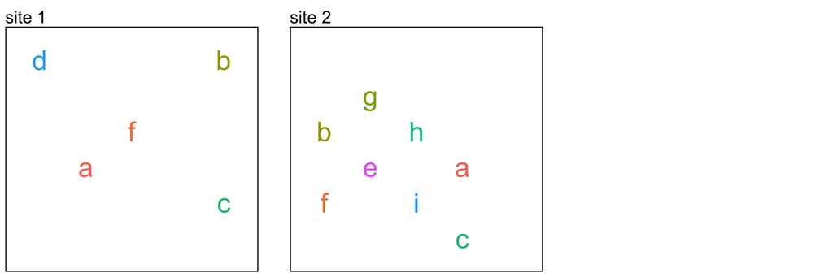

The average (mean) alpha diversity is **6.5** species.

**Step-by-step:**

- Site 1 has 5 species.
- Site 2 has 8 species.
- Mean alpha $= (S_1 + S_2) \div 2 = (5 + 8) \div 2 = 13 \div 2 = 6.5$

Key reminder: even if some species appear in both sites, each site's richness is counted independently. Enter only the numeric value **6.5** for it to register as correct.

**Calculate the *average* alpha diversity between these two wetland sites.** We define "average" as the arithmetic mean: sum the species richness of each site and divide by the number of sites (2). If site 1 has richness $S_1$ and site 2 has richness $S_2$, the mean alpha is $(S_1 + S_2) \div 2$.

Note: the mean alpha diversity is *not* the count of unique species across both sites combined — it is the sum of each site's own richness, divided by the number of sites. Shared species count separately in each site's richness.

**Input a numeric value; round to one decimal place.** If the answer is a whole number, still write $.0$ (e.g., $6.0$).

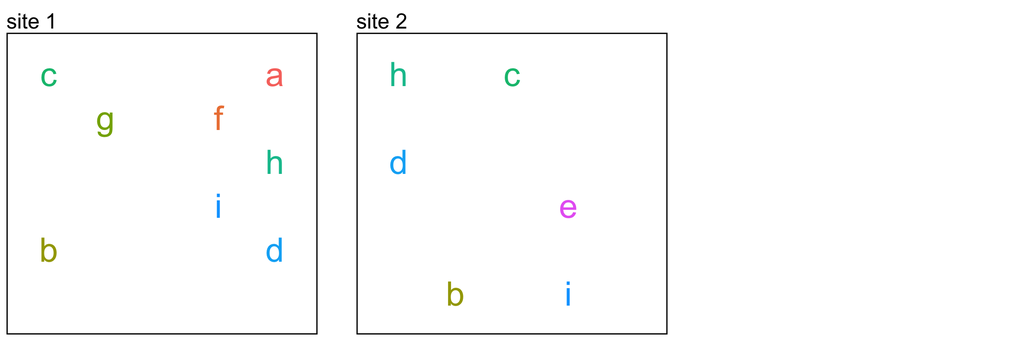

The average (mean) alpha diversity is **7** species.

**Step-by-step:**

- Site 1 has 8 species.
- Site 2 has 6 species.
- Mean alpha $= (S_1 + S_2) \div 2 = (8 + 6) \div 2 = 14 \div 2 = 7$

Key reminder: even if some species appear in both sites, each site's richness is counted independently. Enter only the numeric value **7** for it to register as correct.

**Calculate the *average* alpha diversity between these two wetland sites.** We define "average" as the arithmetic mean: sum the species richness of each site and divide by the number of sites (2). If site 1 has richness $S_1$ and site 2 has richness $S_2$, the mean alpha is $(S_1 + S_2) \div 2$.

Note: the mean alpha diversity is *not* the count of unique species across both sites combined — it is the sum of each site's own richness, divided by the number of sites. Shared species count separately in each site's richness.

**Input a numeric value; round to one decimal place.** If the answer is a whole number, still write $.0$ (e.g., $6.0$).

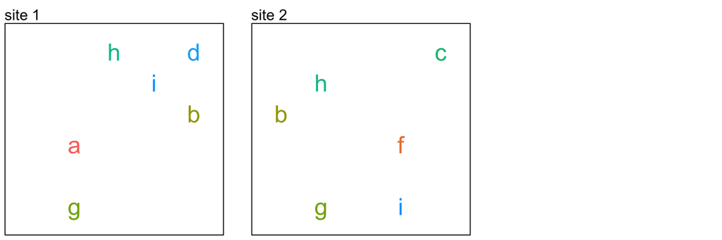

The average (mean) alpha diversity is **6** species.

**Step-by-step:**

- Site 1 has 6 species.
- Site 2 has 6 species.
- Mean alpha $= (S_1 + S_2) \div 2 = (6 + 6) \div 2 = 12 \div 2 = 6$

Key reminder: even if some species appear in both sites, each site's richness is counted independently. Enter only the numeric value **6** for it to register as correct.

**Calculate the gamma diversity of these two coral reef sites.** Gamma diversity is the total species richness across the two sites combined. If a species is found in both sites, count it only once — do *not* count it once per site. Input an integer (whole number).

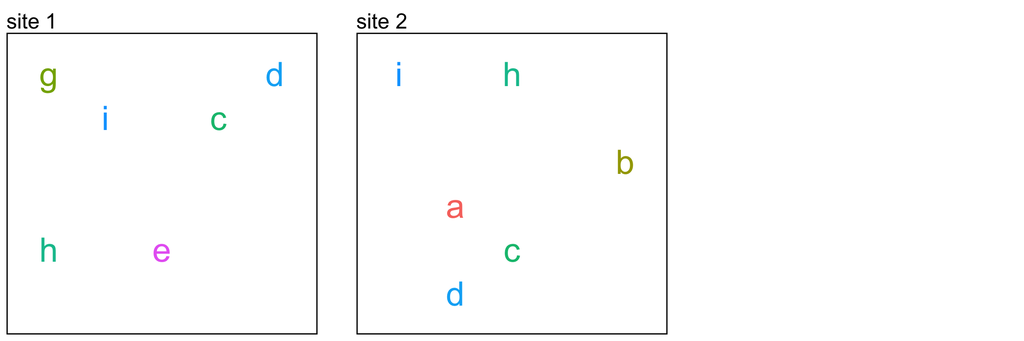

The species present across both sites are: **a, b, c, d, e, g, h, i**. There are thus **8** total species — the gamma diversity.

**How to solve this:** Compile a list of all species (letters) appearing in either site. Any species appearing in both sites is still counted only once. The full set of unique species is: a, b, c, d, e, g, h, i. Count them: **8** species.

Common mistake: gamma diversity is species richness (count of species), not the number of individual organisms.

**Calculate the gamma diversity of these two coral reef sites.** Gamma diversity is the total species richness across the two sites combined. If a species is found in both sites, count it only once — do *not* count it once per site. Input an integer (whole number).

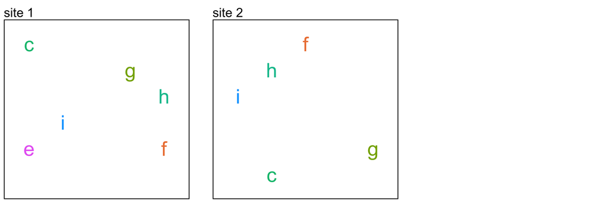

The species present across both sites are: **c, e, f, g, h, i**. There are thus **6** total species — the gamma diversity.

**How to solve this:** Compile a list of all species (letters) appearing in either site. Any species appearing in both sites is still counted only once. The full set of unique species is: c, e, f, g, h, i. Count them: **6** species.

Common mistake: gamma diversity is species richness (count of species), not the number of individual organisms.

**Calculate the gamma diversity of these two coral reef sites.** Gamma diversity is the total species richness across the two sites combined. If a species is found in both sites, count it only once — do *not* count it once per site. Input an integer (whole number).

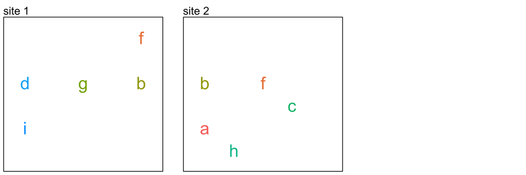

The species present across both sites are: **a, b, c, d, f, g, h, i**. There are thus **8** total species — the gamma diversity.

**How to solve this:** Compile a list of all species (letters) appearing in either site. Any species appearing in both sites is still counted only once. The full set of unique species is: a, b, c, d, f, g, h, i. Count them: **8** species.

Common mistake: gamma diversity is species richness (count of species), not the number of individual organisms.

**Calculate the gamma diversity of these two coral reef sites.** Gamma diversity is the total species richness across the two sites combined. If a species is found in both sites, count it only once — do *not* count it once per site. Input an integer (whole number).

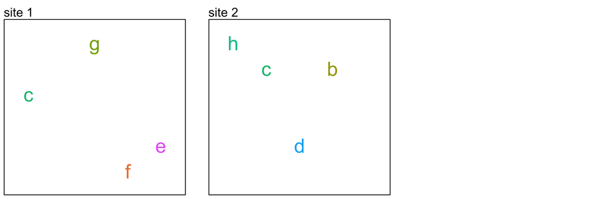

The species present across both sites are: **b, c, d, e, f, g, h**. There are thus **7** total species — the gamma diversity.

**How to solve this:** Compile a list of all species (letters) appearing in either site. Any species appearing in both sites is still counted only once. The full set of unique species is: b, c, d, e, f, g, h. Count them: **7** species.

Common mistake: gamma diversity is species richness (count of species), not the number of individual organisms.

**Calculate the gamma diversity of these two coral reef sites.** Gamma diversity is the total species richness across the two sites combined. If a species is found in both sites, count it only once — do *not* count it once per site. Input an integer (whole number).

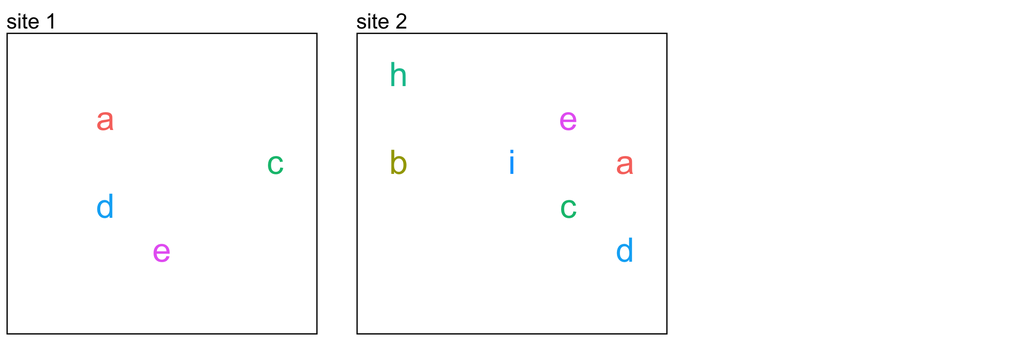

The species present across both sites are: **a, b, c, d, e, h, i**. There are thus **7** total species — the gamma diversity.

**How to solve this:** Compile a list of all species (letters) appearing in either site. Any species appearing in both sites is still counted only once. The full set of unique species is: a, b, c, d, e, h, i. Count them: **7** species.

Common mistake: gamma diversity is species richness (count of species), not the number of individual organisms.

**Calculate the gamma diversity of these two coral reef sites.** Gamma diversity is the total species richness across the two sites combined. If a species is found in both sites, count it only once — do *not* count it once per site. Input an integer (whole number).

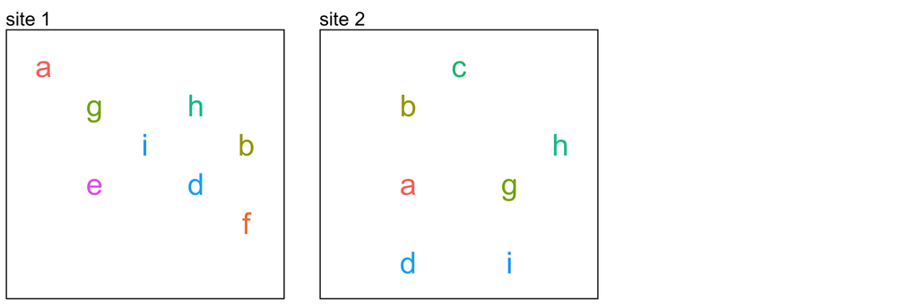

The species present across both sites are: **a, b, c, d, e, f, g, h, i**. There are thus **9** total species — the gamma diversity.

**How to solve this:** Compile a list of all species (letters) appearing in either site. Any species appearing in both sites is still counted only once. The full set of unique species is: a, b, c, d, e, f, g, h, i. Count them: **9** species.

Common mistake: gamma diversity is species richness (count of species), not the number of individual organisms.

**Calculate the gamma diversity of these two coral reef sites.** Gamma diversity is the total species richness across the two sites combined. If a species is found in both sites, count it only once — do *not* count it once per site. Input an integer (whole number).

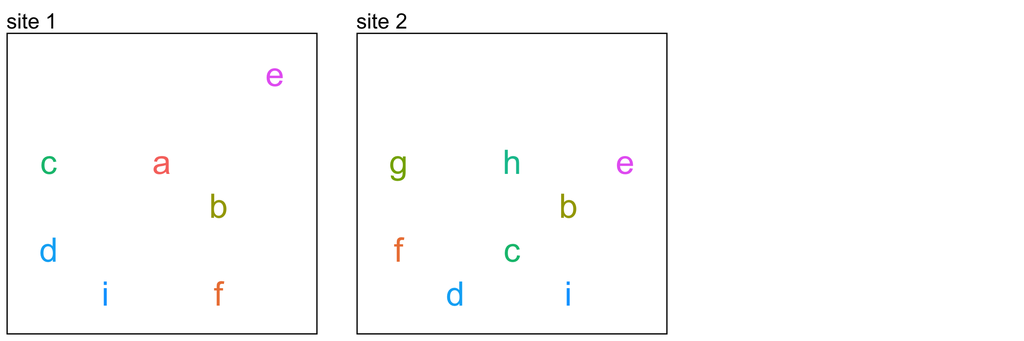

The species present across both sites are: **a, b, c, d, e, f, g, h, i**. There are thus **9** total species — the gamma diversity.

**How to solve this:** Compile a list of all species (letters) appearing in either site. Any species appearing in both sites is still counted only once. The full set of unique species is: a, b, c, d, e, f, g, h, i. Count them: **9** species.

Common mistake: gamma diversity is species richness (count of species), not the number of individual organisms.

**Calculate the gamma diversity of these four alpine meadow sites.** Gamma diversity is the total species richness across all four sites. If a species is found in more than one site, count it once only — do *not* count it once per site. Input an integer (whole number).

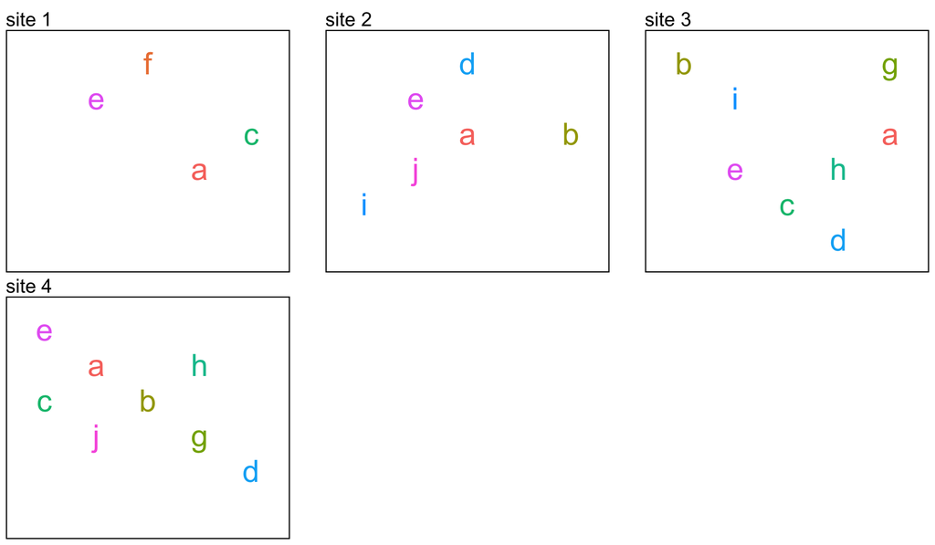

The species present across all four sites are: **a, b, c, d, e, f, g, h, i, j**. There are thus **10** total species — the gamma diversity.

**How to solve this:** Work through each site in turn, adding any new species (letters) you haven't yet seen to your running list. When all four sites have been checked, count the total unique species in your list. The full set here is: a, b, c, d, e, f, g, h, i, j, totaling **10** species.

**Calculate the gamma diversity of these four alpine meadow sites.** Gamma diversity is the total species richness across all four sites. If a species is found in more than one site, count it once only — do *not* count it once per site. Input an integer (whole number).

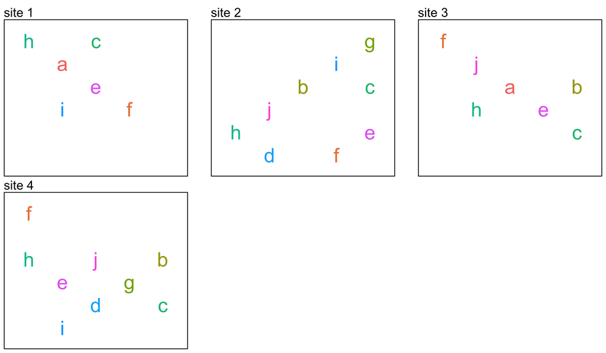

The species present across all four sites are: **a, b, c, d, e, f, g, h, i, j**. There are thus **10** total species — the gamma diversity.

**How to solve this:** Work through each site in turn, adding any new species (letters) you haven't yet seen to your running list. When all four sites have been checked, count the total unique species in your list. The full set here is: a, b, c, d, e, f, g, h, i, j, totaling **10** species.

**Calculate the gamma diversity of these four alpine meadow sites.** Gamma diversity is the total species richness across all four sites. If a species is found in more than one site, count it once only — do *not* count it once per site. Input an integer (whole number).

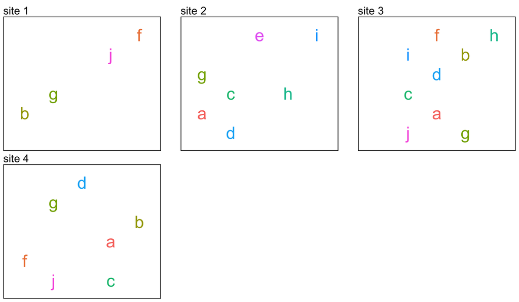

The species present across all four sites are: **a, b, c, d, e, f, g, h, i, j**. There are thus **10** total species — the gamma diversity.

**How to solve this:** Work through each site in turn, adding any new species (letters) you haven't yet seen to your running list. When all four sites have been checked, count the total unique species in your list. The full set here is: a, b, c, d, e, f, g, h, i, j, totaling **10** species.

**Calculate the gamma diversity of these four alpine meadow sites.** Gamma diversity is the total species richness across all four sites. If a species is found in more than one site, count it once only — do *not* count it once per site. Input an integer (whole number).

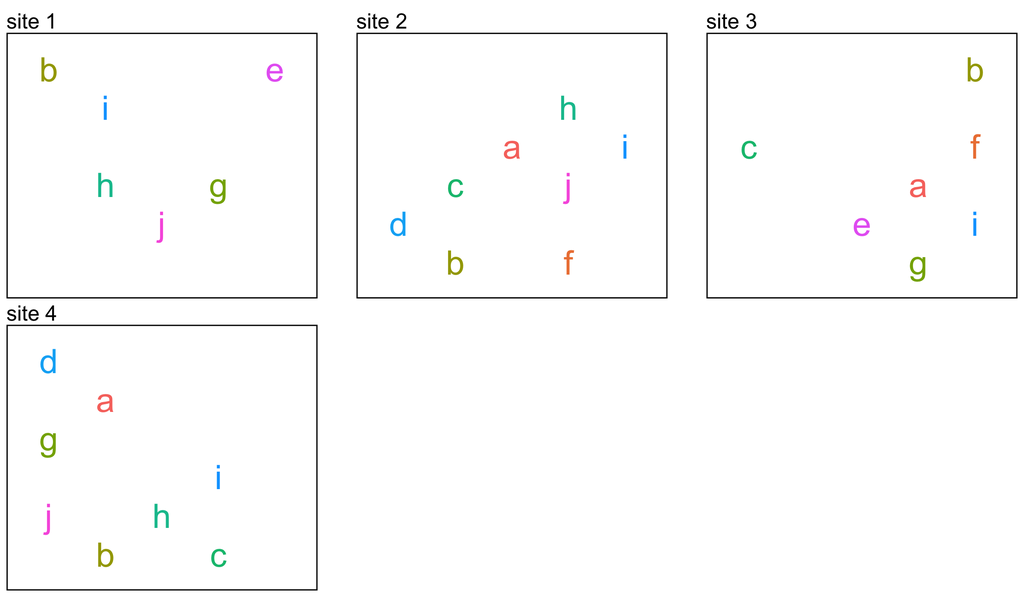

The species present across all four sites are: **a, b, c, d, e, f, g, h, i, j**. There are thus **10** total species — the gamma diversity.

**How to solve this:** Work through each site in turn, adding any new species (letters) you haven't yet seen to your running list. When all four sites have been checked, count the total unique species in your list. The full set here is: a, b, c, d, e, f, g, h, i, j, totaling **10** species.

**Calculate the gamma diversity of these four alpine meadow sites.** Gamma diversity is the total species richness across all four sites. If a species is found in more than one site, count it once only — do *not* count it once per site. Input an integer (whole number).

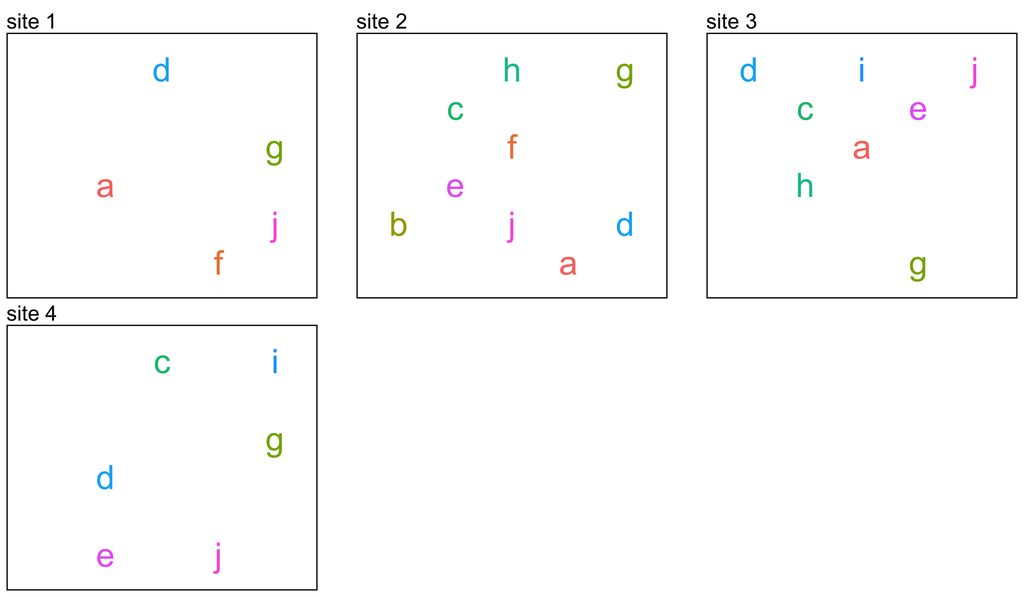

The species present across all four sites are: **a, b, c, d, e, f, g, h, i, j**. There are thus **10** total species — the gamma diversity.

**How to solve this:** Work through each site in turn, adding any new species (letters) you haven't yet seen to your running list. When all four sites have been checked, count the total unique species in your list. The full set here is: a, b, c, d, e, f, g, h, i, j, totaling **10** species.

**Calculate the gamma diversity of these four alpine meadow sites.** Gamma diversity is the total species richness across all four sites. If a species is found in more than one site, count it once only — do *not* count it once per site. Input an integer (whole number).

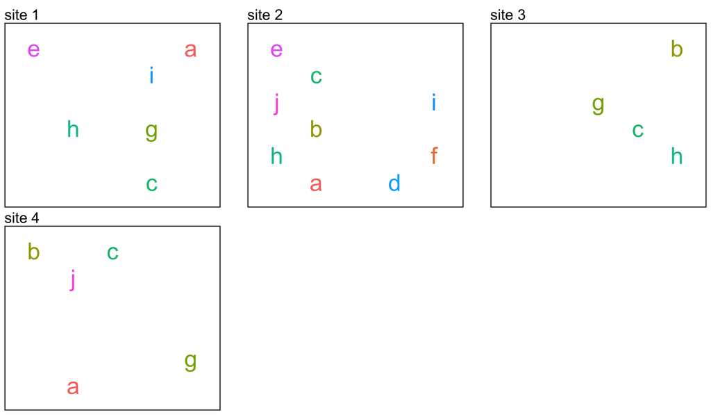

The species present across all four sites are: **a, b, c, d, e, f, g, h, i, j**. There are thus **10** total species — the gamma diversity.

**How to solve this:** Work through each site in turn, adding any new species (letters) you haven't yet seen to your running list. When all four sites have been checked, count the total unique species in your list. The full set here is: a, b, c, d, e, f, g, h, i, j, totaling **10** species.

**Calculate the gamma diversity of these four alpine meadow sites.** Gamma diversity is the total species richness across all four sites. If a species is found in more than one site, count it once only — do *not* count it once per site. Input an integer (whole number).

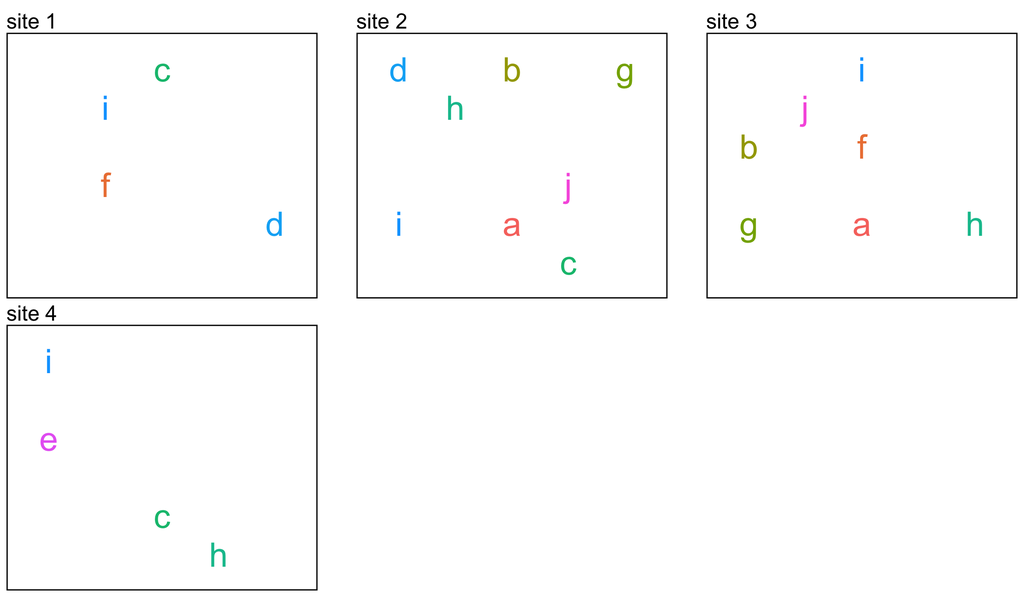

The species present across all four sites are: **a, b, c, d, e, f, g, h, i, j**. There are thus **10** total species — the gamma diversity.

**How to solve this:** Work through each site in turn, adding any new species (letters) you haven't yet seen to your running list. When all four sites have been checked, count the total unique species in your list. The full set here is: a, b, c, d, e, f, g, h, i, j, totaling **10** species.

**Calculate the beta diversity of these two desert scrub sites.** Beta diversity is defined as:

$$\beta = \gamma \div
\overline{\alpha}$$

where $\gamma$ is gamma diversity (total species richness across both sites) and $\overline{\alpha}$ is mean alpha diversity (average species richness per site). **Input a numeric value** rounded to two digits.

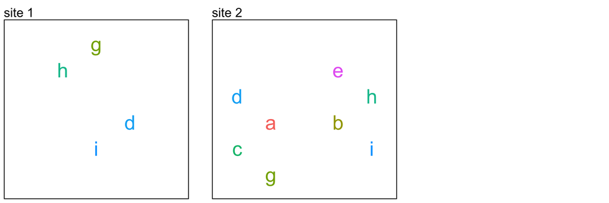

**Step 1 — Gamma diversity ($\gamma$):** list all unique species across both sites.

Species present: a, b, c, d, e, g, h, i. Therefore $\gamma$ = **8**.

**Step 2 — Mean alpha diversity ($\overline{\alpha}$):** average the richness of each site.

$$\overline{\alpha} = (4 + 8) \div 2 = 12
\div 2 = 6$$

**Step 3 — Beta diversity ($\beta$):**

$$\beta = \gamma \div \overline{\alpha} =
8 \div 6 = 1.3333333$$

Rounded to two digits: **$\beta =$ 1.33**.

Intuition: $\beta$ measures how much community composition changes across sites. A $\beta$ near 1 means the sites share most of their species; higher $\beta$ means more turnover (distinct species in each site).

Enter only the numeric value **1.33** for it to register as correct.

**Calculate the beta diversity of these two desert scrub sites.** Beta diversity is defined as:

$$\beta = \gamma \div
\overline{\alpha}$$

where $\gamma$ is gamma diversity (total species richness across both sites) and $\overline{\alpha}$ is mean alpha diversity (average species richness per site). **Input a numeric value** rounded to two digits.

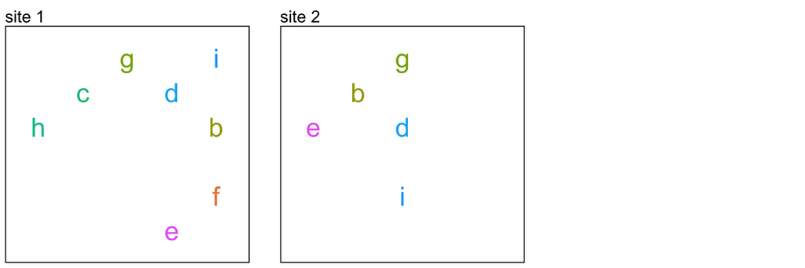

**Step 1 — Gamma diversity ($\gamma$):** list all unique species across both sites.

Species present: b, c, d, e, f, g, h, i. Therefore $\gamma$ = **8**.

**Step 2 — Mean alpha diversity ($\overline{\alpha}$):** average the richness of each site.

$$\overline{\alpha} = (8 + 5) \div 2 = 13
\div 2 = 6.5$$

**Step 3 — Beta diversity ($\beta$):**

$$\beta = \gamma \div \overline{\alpha} =
8 \div 6.5 = 1.2307692$$

Rounded to two digits: **$\beta =$ 1.23**.

Intuition: $\beta$ measures how much community composition changes across sites. A $\beta$ near 1 means the sites share most of their species; higher $\beta$ means more turnover (distinct species in each site).

Enter only the numeric value **1.23** for it to register as correct.

**Calculate the beta diversity of these two desert scrub sites.** Beta diversity is defined as:

$$\beta = \gamma \div
\overline{\alpha}$$

where $\gamma$ is gamma diversity (total species richness across both sites) and $\overline{\alpha}$ is mean alpha diversity (average species richness per site). **Input a numeric value** rounded to two digits.

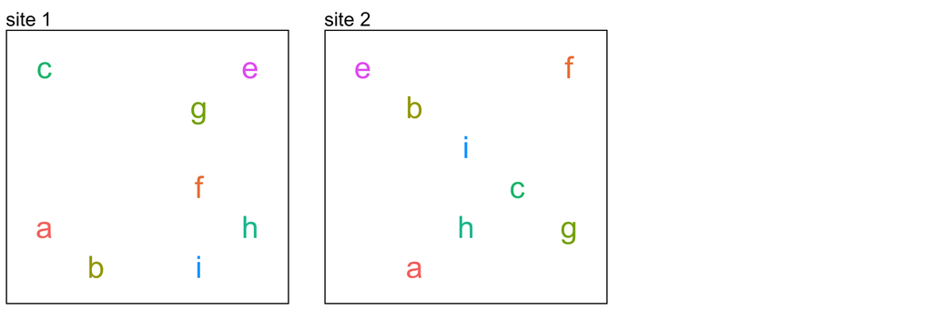

**Step 1 — Gamma diversity ($\gamma$):** list all unique species across both sites.

Species present: a, b, c, e, f, g, h, i. Therefore $\gamma$ = **8**.

**Step 2 — Mean alpha diversity ($\overline{\alpha}$):** average the richness of each site.

$$\overline{\alpha} = (8 + 8) \div 2 = 16
\div 2 = 8$$

**Step 3 — Beta diversity ($\beta$):**

$$\beta = \gamma \div \overline{\alpha} =
8 \div 8 = 1$$

Rounded to two digits: **$\beta =$ 1**.

Intuition: $\beta$ measures how much community composition changes across sites. A $\beta$ near 1 means the sites share most of their species; higher $\beta$ means more turnover (distinct species in each site).

Enter only the numeric value **1** for it to register as correct.

**Calculate the beta diversity of these two desert scrub sites.** Beta diversity is defined as:

$$\beta = \gamma \div
\overline{\alpha}$$

where $\gamma$ is gamma diversity (total species richness across both sites) and $\overline{\alpha}$ is mean alpha diversity (average species richness per site). **Input a numeric value** rounded to two digits.

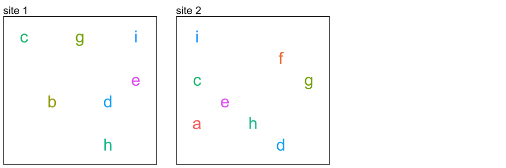

**Step 1 — Gamma diversity ($\gamma$):** list all unique species across both sites.

Species present: a, b, c, d, e, f, g, h, i. Therefore $\gamma$ = **9**.

**Step 2 — Mean alpha diversity ($\overline{\alpha}$):** average the richness of each site.

$$\overline{\alpha} = (7 + 8) \div 2 = 15
\div 2 = 7.5$$

**Step 3 — Beta diversity ($\beta$):**

$$\beta = \gamma \div \overline{\alpha} =
9 \div 7.5 = 1.2$$

Rounded to two digits: **$\beta =$ 1.2**.

Intuition: $\beta$ measures how much community composition changes across sites. A $\beta$ near 1 means the sites share most of their species; higher $\beta$ means more turnover (distinct species in each site).

Enter only the numeric value **1.2** for it to register as correct.

**Calculate the beta diversity of these two desert scrub sites.** Beta diversity is defined as:

$$\beta = \gamma \div
\overline{\alpha}$$

where $\gamma$ is gamma diversity (total species richness across both sites) and $\overline{\alpha}$ is mean alpha diversity (average species richness per site). **Input a numeric value** rounded to two digits.

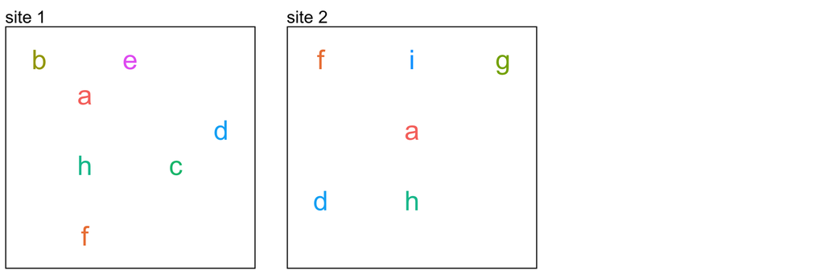

**Step 1 — Gamma diversity ($\gamma$):** list all unique species across both sites.

Species present: a, b, c, d, e, f, g, h, i. Therefore $\gamma$ = **9**.

**Step 2 — Mean alpha diversity ($\overline{\alpha}$):** average the richness of each site.

$$\overline{\alpha} = (7 + 6) \div 2 = 13
\div 2 = 6.5$$

**Step 3 — Beta diversity ($\beta$):**

$$\beta = \gamma \div \overline{\alpha} =
9 \div 6.5 = 1.3846154$$

Rounded to two digits: **$\beta =$ 1.38**.

Intuition: $\beta$ measures how much community composition changes across sites. A $\beta$ near 1 means the sites share most of their species; higher $\beta$ means more turnover (distinct species in each site).

Enter only the numeric value **1.38** for it to register as correct.

**Calculate the beta diversity of these two desert scrub sites.** Beta diversity is defined as:

$$\beta = \gamma \div
\overline{\alpha}$$

where $\gamma$ is gamma diversity (total species richness across both sites) and $\overline{\alpha}$ is mean alpha diversity (average species richness per site). **Input a numeric value** rounded to two digits.

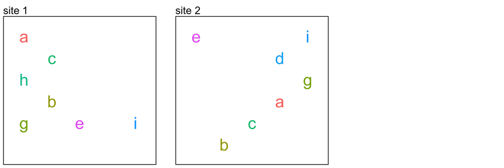

**Step 1 — Gamma diversity ($\gamma$):** list all unique species across both sites.

Species present: a, b, c, d, e, g, h, i. Therefore $\gamma$ = **8**.

**Step 2 — Mean alpha diversity ($\overline{\alpha}$):** average the richness of each site.

$$\overline{\alpha} = (7 + 7) \div 2 = 14
\div 2 = 7$$

**Step 3 — Beta diversity ($\beta$):**

$$\beta = \gamma \div \overline{\alpha} =
8 \div 7 = 1.1428571$$

Rounded to two digits: **$\beta =$ 1.14**.

Intuition: $\beta$ measures how much community composition changes across sites. A $\beta$ near 1 means the sites share most of their species; higher $\beta$ means more turnover (distinct species in each site).

Enter only the numeric value **1.14** for it to register as correct.

**Calculate the beta diversity of these two desert scrub sites.** Beta diversity is defined as:

$$\beta = \gamma \div
\overline{\alpha}$$

where $\gamma$ is gamma diversity (total species richness across both sites) and $\overline{\alpha}$ is mean alpha diversity (average species richness per site). **Input a numeric value** rounded to two digits.

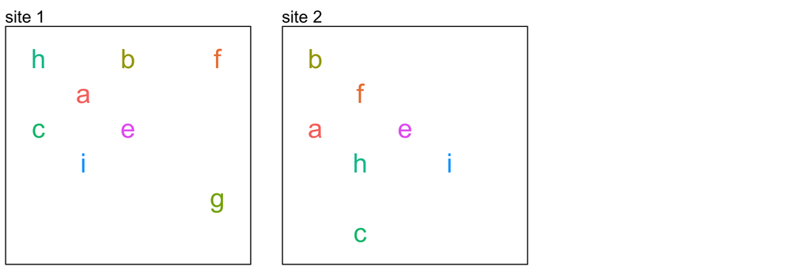

**Step 1 — Gamma diversity ($\gamma$):** list all unique species across both sites.

Species present: a, b, c, e, f, g, h, i. Therefore $\gamma$ = **8**.

**Step 2 — Mean alpha diversity ($\overline{\alpha}$):** average the richness of each site.

$$\overline{\alpha} = (8 + 7) \div 2 = 15
\div 2 = 7.5$$

**Step 3 — Beta diversity ($\beta$):**

$$\beta = \gamma \div \overline{\alpha} =
8 \div 7.5 = 1.0666667$$

Rounded to two digits: **$\beta =$ 1.07**.

Intuition: $\beta$ measures how much community composition changes across sites. A $\beta$ near 1 means the sites share most of their species; higher $\beta$ means more turnover (distinct species in each site).

Enter only the numeric value **1.07** for it to register as correct.

**Calculate the beta diversity of these four tropical forest plots.** Beta diversity is defined as:

$$\beta = \gamma \div
\overline{\alpha}$$

where $\gamma$ is gamma diversity (total species richness across all four sites) and $\overline{\alpha}$ is mean alpha diversity (average species richness per site). **Input a numeric value** rounded to two or fewer digits.

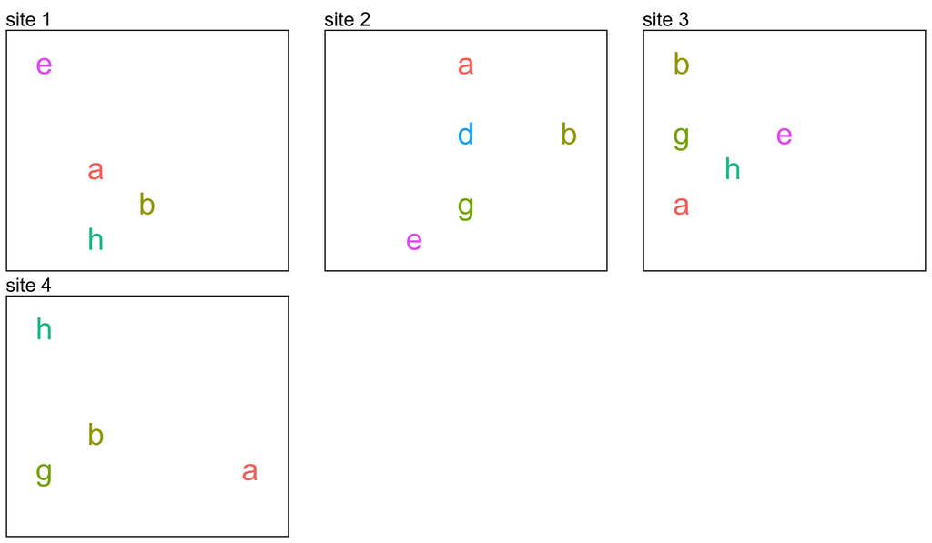

**Step 1 — Gamma diversity ($\gamma$):** compile all unique species across all four sites.

Species present: a, b, d, e, g, h. Therefore $\gamma$ = **6**.

**Step 2 — Mean alpha diversity ($\overline{\alpha}$):**

$$\overline{\alpha} = (4 + 5 + 5 + 4) \div
4 = 18 \div 4 = 4.5$$

**Step 3 — Beta diversity ($\beta$):**

$$\beta = 6 \div 4.5 =
1.3333333$$

Rounded to two digits: **$\beta =$ 1.33**.

Enter only the numeric value for it to register as correct.

**Calculate the beta diversity of these four tropical forest plots.** Beta diversity is defined as:

$$\beta = \gamma \div
\overline{\alpha}$$

where $\gamma$ is gamma diversity (total species richness across all four sites) and $\overline{\alpha}$ is mean alpha diversity (average species richness per site). **Input a numeric value** rounded to two or fewer digits.

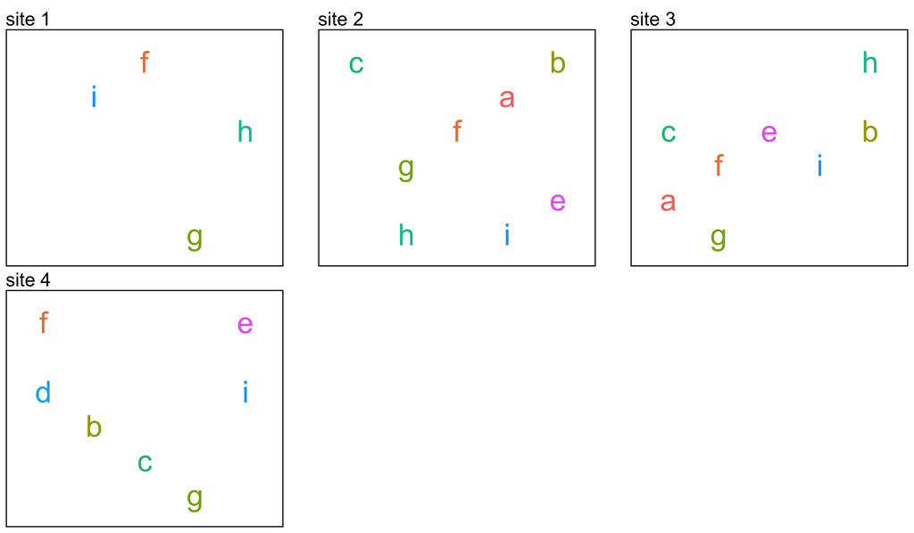

**Step 1 — Gamma diversity ($\gamma$):** compile all unique species across all four sites.

Species present: a, b, c, d, e, f, g, h, i. Therefore $\gamma$ = **9**.

**Step 2 — Mean alpha diversity ($\overline{\alpha}$):**

$$\overline{\alpha} = (4 + 8 + 8 + 7) \div
4 = 27 \div 4 = 6.75$$

**Step 3 — Beta diversity ($\beta$):**

$$\beta = 9 \div 6.75 =
1.3333333$$

Rounded to two digits: **$\beta =$ 1.33**.

Enter only the numeric value for it to register as correct.

**Calculate the beta diversity of these four tropical forest plots.** Beta diversity is defined as:

$$\beta = \gamma \div
\overline{\alpha}$$

where $\gamma$ is gamma diversity (total species richness across all four sites) and $\overline{\alpha}$ is mean alpha diversity (average species richness per site). **Input a numeric value** rounded to two or fewer digits.

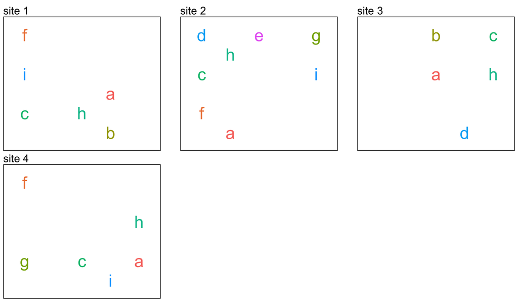

**Step 1 — Gamma diversity ($\gamma$):** compile all unique species across all four sites.

Species present: a, b, c, d, e, f, g, h, i. Therefore $\gamma$ = **9**.

**Step 2 — Mean alpha diversity ($\overline{\alpha}$):**

$$\overline{\alpha} = (6 + 8 + 5 + 6) \div
4 = 25 \div 4 = 6.25$$

**Step 3 — Beta diversity ($\beta$):**

$$\beta = 9 \div 6.25 = 1.44$$

Rounded to two digits: **$\beta =$ 1.44**.

Enter only the numeric value for it to register as correct.

**Calculate the beta diversity of these four tropical forest plots.** Beta diversity is defined as:

$$\beta = \gamma \div
\overline{\alpha}$$

where $\gamma$ is gamma diversity (total species richness across all four sites) and $\overline{\alpha}$ is mean alpha diversity (average species richness per site). **Input a numeric value** rounded to two or fewer digits.

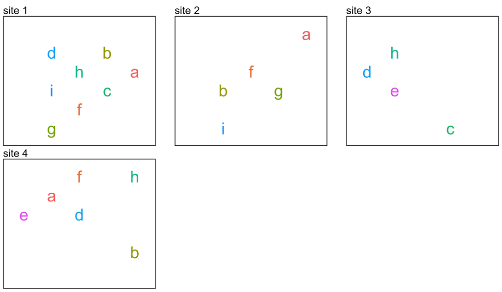

**Step 1 — Gamma diversity ($\gamma$):** compile all unique species across all four sites.

Species present: a, b, c, d, e, f, g, h, i. Therefore $\gamma$ = **9**.

**Step 2 — Mean alpha diversity ($\overline{\alpha}$):**

$$\overline{\alpha} = (8 + 5 + 4 + 6) \div
4 = 23 \div 4 = 5.75$$

**Step 3 — Beta diversity ($\beta$):**

$$\beta = 9 \div 5.75 =
1.5652174$$

Rounded to two digits: **$\beta =$ 1.57**.

Enter only the numeric value for it to register as correct.

**Calculate the beta diversity of these four tropical forest plots.** Beta diversity is defined as:

$$\beta = \gamma \div
\overline{\alpha}$$

where $\gamma$ is gamma diversity (total species richness across all four sites) and $\overline{\alpha}$ is mean alpha diversity (average species richness per site). **Input a numeric value** rounded to two or fewer digits.

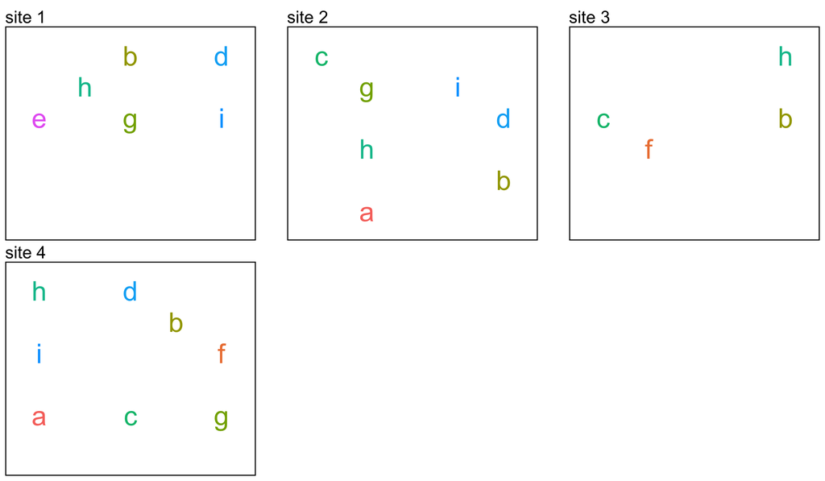

**Step 1 — Gamma diversity ($\gamma$):** compile all unique species across all four sites.

Species present: a, b, c, d, e, f, g, h, i. Therefore $\gamma$ = **9**.

**Step 2 — Mean alpha diversity ($\overline{\alpha}$):**

$$\overline{\alpha} = (6 + 7 + 4 + 8) \div
4 = 25 \div 4 = 6.25$$

**Step 3 — Beta diversity ($\beta$):**

$$\beta = 9 \div 6.25 = 1.44$$

Rounded to two digits: **$\beta =$ 1.44**.

Enter only the numeric value for it to register as correct.

**Calculate the beta diversity of these four tropical forest plots.** Beta diversity is defined as:

$$\beta = \gamma \div
\overline{\alpha}$$

where $\gamma$ is gamma diversity (total species richness across all four sites) and $\overline{\alpha}$ is mean alpha diversity (average species richness per site). **Input a numeric value** rounded to two or fewer digits.

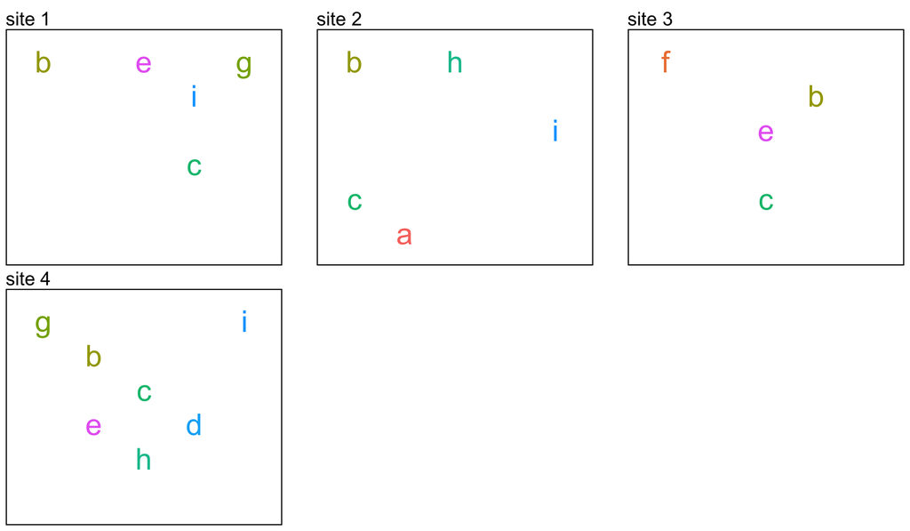

**Step 1 — Gamma diversity ($\gamma$):** compile all unique species across all four sites.

Species present: a, b, c, d, e, f, g, h, i. Therefore $\gamma$ = **9**.

**Step 2 — Mean alpha diversity ($\overline{\alpha}$):**

$$\overline{\alpha} = (5 + 5 + 4 + 7) \div
4 = 21 \div 4 = 5.25$$

**Step 3 — Beta diversity ($\beta$):**

$$\beta = 9 \div 5.25 =
1.7142857$$

Rounded to two digits: **$\beta =$ 1.71**.

Enter only the numeric value for it to register as correct.

**Calculate the beta diversity of these four tropical forest plots.** Beta diversity is defined as:

$$\beta = \gamma \div
\overline{\alpha}$$

where $\gamma$ is gamma diversity (total species richness across all four sites) and $\overline{\alpha}$ is mean alpha diversity (average species richness per site). **Input a numeric value** rounded to two or fewer digits.

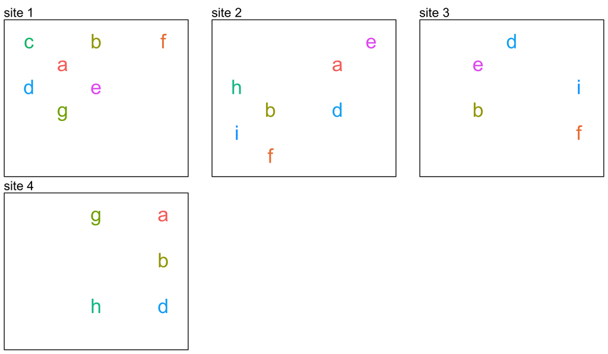

**Step 1 — Gamma diversity ($\gamma$):** compile all unique species across all four sites.

Species present: a, b, c, d, e, f, g, h, i. Therefore $\gamma$ = **9**.

**Step 2 — Mean alpha diversity ($\overline{\alpha}$):**

$$\overline{\alpha} = (7 + 7 + 5 + 5) \div
4 = 24 \div 4 = 6$$

**Step 3 — Beta diversity ($\beta$):**

$$\beta = 9 \div 6 = 1.5$$

Rounded to two digits: **$\beta =$ 1.5**.

Enter only the numeric value for it to register as correct.

**A regional water authority manages six freshwater pond sites. Due to budget constraints, they can only actively restore and protect three of them. To best support regional biodiversity, the authority wants to choose the three sites that together contain the highest gamma diversity (total species richness across all three chosen sites). Which three sites should they protect?**

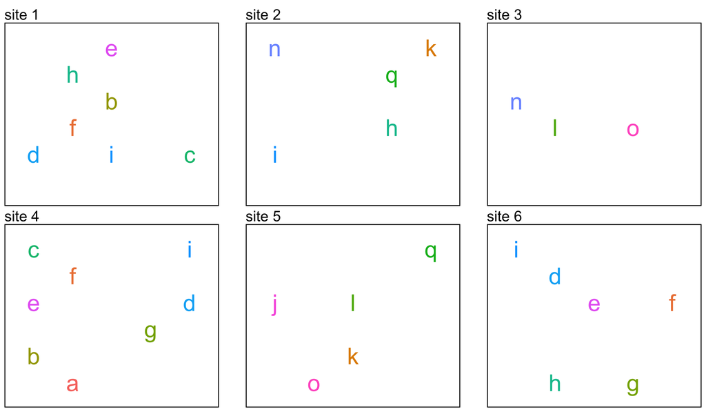

The three sites that together maximize gamma diversity are: **s2, s4, s5**.

Across these three sites there are 15 species: a, b, c, d, e, f, g, h, i, j, k, l, n, o, q

**Recommended strategy (not guaranteed to work 100% of the time, but usually efficient):**

1. Start with the site that has the most species (highest alpha).
2. Of the remaining sites, find the one that contributes the most *new* (non-overlapping) species when added to your selection.
3. Repeat for the third site: which remaining site adds the most new species to what you've already selected?
4. Double-check by repeating the process starting from the second-highest alpha site — sometimes this yields higher overall gamma.

With 6 sites there are 20 possible combinations of 3. The strategic approach usually avoids having to evaluate all of them.

**A regional water authority manages six freshwater pond sites. Due to budget constraints, they can only actively restore and protect three of them. To best support regional biodiversity, the authority wants to choose the three sites that together contain the highest gamma diversity (total species richness across all three chosen sites). Which three sites should they protect?**

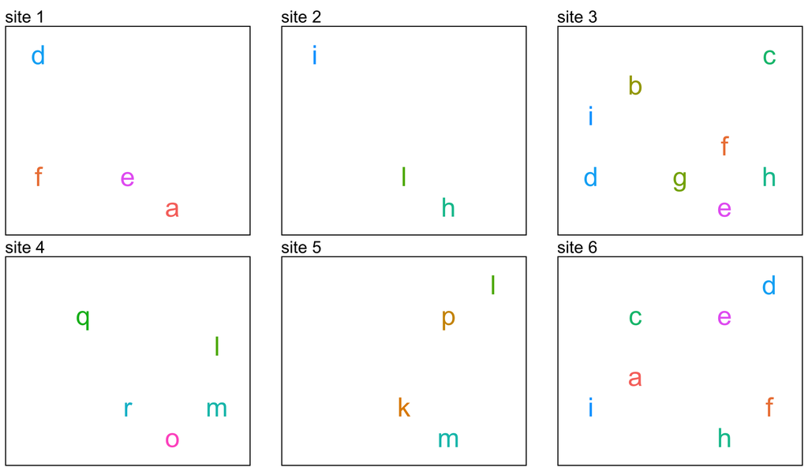

The three sites that together maximize gamma diversity are: **s3, s4, s5**.

Across these three sites there are 15 species: b, c, d, e, f, g, h, i, k, l, m, o, p, q, r

**Recommended strategy (not guaranteed to work 100% of the time, but usually efficient):**

1. Start with the site that has the most species (highest alpha).
2. Of the remaining sites, find the one that contributes the most *new* (non-overlapping) species when added to your selection.
3. Repeat for the third site: which remaining site adds the most new species to what you've already selected?
4. Double-check by repeating the process starting from the second-highest alpha site — sometimes this yields higher overall gamma.

With 6 sites there are 20 possible combinations of 3. The strategic approach usually avoids having to evaluate all of them.

**A regional water authority manages six freshwater pond sites. Due to budget constraints, they can only actively restore and protect three of them. To best support regional biodiversity, the authority wants to choose the three sites that together contain the highest gamma diversity (total species richness across all three chosen sites). Which three sites should they protect?**

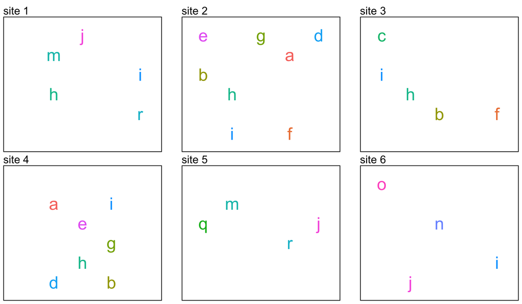

The three sites that together maximize gamma diversity are: **s2, s5, s6**.

Across these three sites there are 14 species: a, b, d, e, f, g, h, i, j, m, n, o, q, r

**Recommended strategy (not guaranteed to work 100% of the time, but usually efficient):**

1. Start with the site that has the most species (highest alpha).
2. Of the remaining sites, find the one that contributes the most *new* (non-overlapping) species when added to your selection.
3. Repeat for the third site: which remaining site adds the most new species to what you've already selected?
4. Double-check by repeating the process starting from the second-highest alpha site — sometimes this yields higher overall gamma.

With 6 sites there are 20 possible combinations of 3. The strategic approach usually avoids having to evaluate all of them.

**A regional water authority manages six freshwater pond sites. Due to budget constraints, they can only actively restore and protect three of them. To best support regional biodiversity, the authority wants to choose the three sites that together contain the highest gamma diversity (total species richness across all three chosen sites). Which three sites should they protect?**

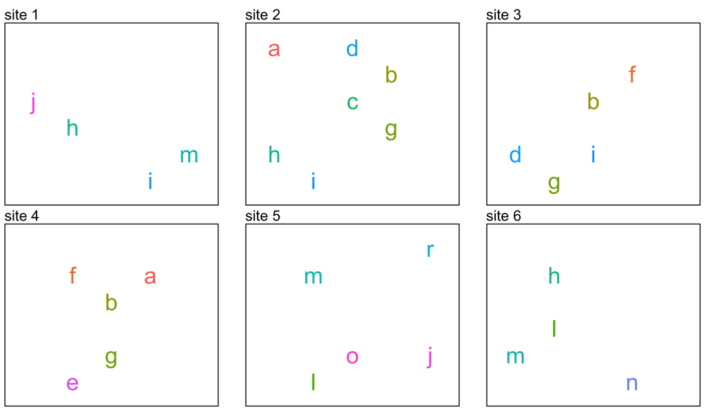

The three sites that together maximize gamma diversity are: **s2, s4, s5**.

Across these three sites there are 14 species: a, b, c, d, e, f, g, h, i, j, l, m, o, r

**Recommended strategy (not guaranteed to work 100% of the time, but usually efficient):**

1. Start with the site that has the most species (highest alpha).
2. Of the remaining sites, find the one that contributes the most *new* (non-overlapping) species when added to your selection.
3. Repeat for the third site: which remaining site adds the most new species to what you've already selected?
4. Double-check by repeating the process starting from the second-highest alpha site — sometimes this yields higher overall gamma.

With 6 sites there are 20 possible combinations of 3. The strategic approach usually avoids having to evaluate all of them.

**A regional water authority manages six freshwater pond sites. Due to budget constraints, they can only actively restore and protect three of them. To best support regional biodiversity, the authority wants to choose the three sites that together contain the highest gamma diversity (total species richness across all three chosen sites). Which three sites should they protect?**

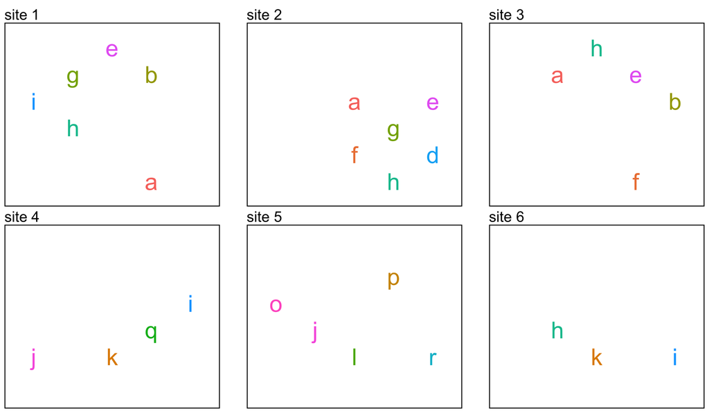

site 1site 2site 3site 4site 5site 6

The three sites that together maximize gamma diversity are: **s2, s4, s5**.

Across these three sites there are 14 species: a, d, e, f, g, h, i, j, k, l, o, p, q, r

**Recommended strategy (not guaranteed to work 100% of the time, but usually efficient):**

1. Start with the site that has the most species (highest alpha).
2. Of the remaining sites, find the one that contributes the most *new* (non-overlapping) species when added to your selection.
3. Repeat for the third site: which remaining site adds the most new species to what you've already selected?
4. Double-check by repeating the process starting from the second-highest alpha site — sometimes this yields higher overall gamma.

With 6 sites there are 20 possible combinations of 3. The strategic approach usually avoids having to evaluate all of them.

**A regional water authority manages six freshwater pond sites. Due to budget constraints, they can only actively restore and protect three of them. To best support regional biodiversity, the authority wants to choose the three sites that together contain the highest gamma diversity (total species richness across all three chosen sites). Which three sites should they protect?**

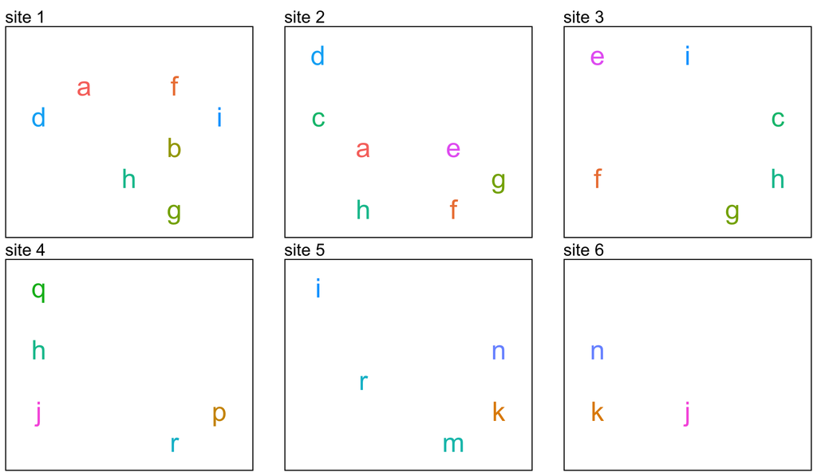

site 1site 2site 3site 4site 5site 6

The three sites that together maximize gamma diversity are: **s2, s4, s5**.

Across these three sites there are 15 species: a, c, d, e, f, g, h, i, j, k, m, n, p, q, r

**Recommended strategy (not guaranteed to work 100% of the time, but usually efficient):**

1. Start with the site that has the most species (highest alpha).
2. Of the remaining sites, find the one that contributes the most *new* (non-overlapping) species when added to your selection.
3. Repeat for the third site: which remaining site adds the most new species to what you've already selected?
4. Double-check by repeating the process starting from the second-highest alpha site — sometimes this yields higher overall gamma.

With 6 sites there are 20 possible combinations of 3. The strategic approach usually avoids having to evaluate all of them.

**A regional water authority manages six freshwater pond sites. Due to budget constraints, they can only actively restore and protect three of them. To best support regional biodiversity, the authority wants to choose the three sites that together contain the highest gamma diversity (total species richness across all three chosen sites). Which three sites should they protect?**

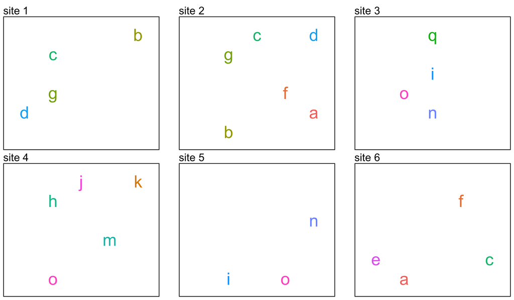

site 1site 2site 3site 4site 5site 6

The three sites that together maximize gamma diversity are: **s2, s3, s4**.

Across these three sites there are 14 species: a, b, c, d, f, g, h, i, j, k, m, n, o, q

**Recommended strategy (not guaranteed to work 100% of the time, but usually efficient):**

1. Start with the site that has the most species (highest alpha).
2. Of the remaining sites, find the one that contributes the most *new* (non-overlapping) species when added to your selection.
3. Repeat for the third site: which remaining site adds the most new species to what you've already selected?
4. Double-check by repeating the process starting from the second-highest alpha site — sometimes this yields higher overall gamma.

With 6 sites there are 20 possible combinations of 3. The strategic approach usually avoids having to evaluate all of them.

**A field ecologist studying habitat complementarity wants to identify which pair of sites shows the greatest turnover in species composition (highest beta diversity). Which pair or pairs of sites (set of two) has the highest beta diversity?** Two or more pairs may share the highest value.

Unlike earlier questions where you calculated a single beta across all sites, here you calculate beta diversity separately for *each possible pair*. For each pair, use only those two sites to compute gamma and mean alpha — not all four sites together.

*You may not need to evaluate all pairs.* Pairs where the two sites share most of their species will have low beta; pairs where the two sites have very different species compositions will have high beta. Remember: $\beta = \gamma \div \overline{\alpha}$, and high $\beta$ results from high $\gamma$ and low $\overline{\alpha}$.

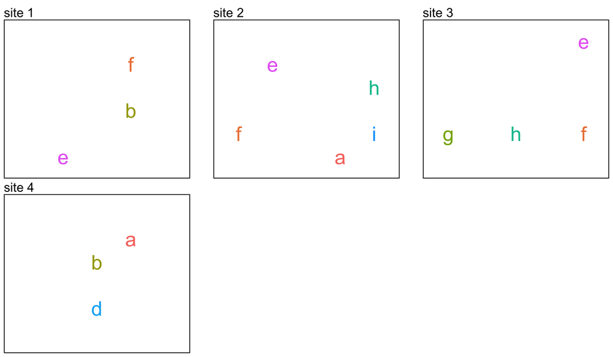

s1, s2s1, s3s1, s4s2, s3s2, s4s3, s4

Here is the complete table of pairwise results (highest-beta pair(s) highlighted):

| Site pair | Mean alpha | Gamma | Beta |
| --- | --- | --- | --- |
| s1, s2 | 4.0 | 6 | 1.50 |
| s1, s3 | 3.5 | 5 | 1.43 |
| s1, s4 | 3.0 | 5 | 1.67 |
| s2, s3 | 4.5 | 6 | 1.33 |
| s2, s4 | 4.0 | 7 | 1.75 |
| s3, s4 | 3.5 | 7 | 2.00 |

The maximum pairwise beta diversity is **2**, found for the pair(s): **s3, s4**.

**How to build this table:**

For each pair of sites (e.g., s1 & s2):

1. Count the species in each site: $\alpha_A$ and $\alpha_B$. Compute $\overline{\alpha} = (\alpha_A + \alpha_B) \div 2$.
2. List all unique species across both sites in the pair to get $\gamma$.
3. Compute $\beta = \gamma \div \overline{\alpha}$, rounded to two digits.

The pair with the highest $\beta$ has the most compositional distinctiveness — the most unique species relative to its average per-site richness.

**A field ecologist studying habitat complementarity wants to identify which pair of sites shows the greatest turnover in species composition (highest beta diversity). Which pair or pairs of sites (set of two) has the highest beta diversity?** Two or more pairs may share the highest value.

Unlike earlier questions where you calculated a single beta across all sites, here you calculate beta diversity separately for *each possible pair*. For each pair, use only those two sites to compute gamma and mean alpha — not all four sites together.

*You may not need to evaluate all pairs.* Pairs where the two sites share most of their species will have low beta; pairs where the two sites have very different species compositions will have high beta. Remember: $\beta = \gamma \div \overline{\alpha}$, and high $\beta$ results from high $\gamma$ and low $\overline{\alpha}$.

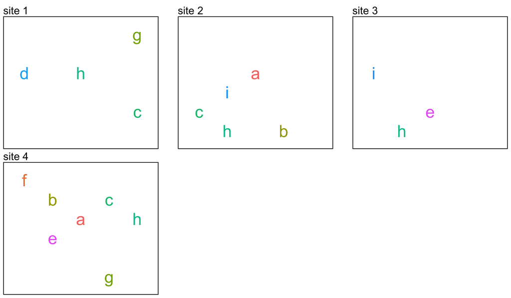

s1, s2s1, s3s1, s4s2, s3s2, s4s3, s4

Here is the complete table of pairwise results (highest-beta pair(s) highlighted):

| Site pair | Mean alpha | Gamma | Beta |
| --- | --- | --- | --- |
| s1, s2 | 4.5 | 7 | 1.56 |
| s1, s3 | 3.5 | 6 | 1.71 |
| s1, s4 | 5.5 | 8 | 1.45 |
| s2, s3 | 4.0 | 6 | 1.50 |
| s2, s4 | 6.0 | 8 | 1.33 |
| s3, s4 | 5.0 | 8 | 1.60 |

The maximum pairwise beta diversity is **1.71**, found for the pair(s): **s1, s3**.

**How to build this table:**

For each pair of sites (e.g., s1 & s2):

1. Count the species in each site: $\alpha_A$ and $\alpha_B$. Compute $\overline{\alpha} = (\alpha_A + \alpha_B) \div 2$.
2. List all unique species across both sites in the pair to get $\gamma$.
3. Compute $\beta = \gamma \div \overline{\alpha}$, rounded to two digits.

The pair with the highest $\beta$ has the most compositional distinctiveness — the most unique species relative to its average per-site richness.

**A field ecologist studying habitat complementarity wants to identify which pair of sites shows the greatest turnover in species composition (highest beta diversity). Which pair or pairs of sites (set of two) has the highest beta diversity?** Two or more pairs may share the highest value.

Unlike earlier questions where you calculated a single beta across all sites, here you calculate beta diversity separately for *each possible pair*. For each pair, use only those two sites to compute gamma and mean alpha — not all four sites together.

*You may not need to evaluate all pairs.* Pairs where the two sites share most of their species will have low beta; pairs where the two sites have very different species compositions will have high beta. Remember: $\beta = \gamma \div \overline{\alpha}$, and high $\beta$ results from high $\gamma$ and low $\overline{\alpha}$.

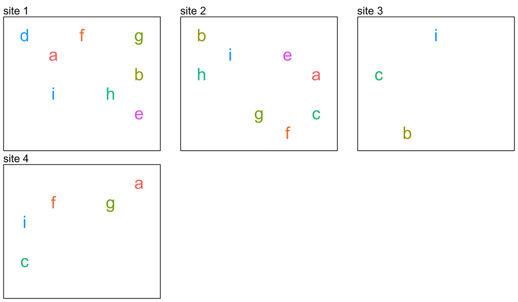

s1, s2s1, s3s1, s4s2, s3s2, s4s3, s4

Here is the complete table of pairwise results (highest-beta pair(s) highlighted):

| Site pair | Mean alpha | Gamma | Beta |
| --- | --- | --- | --- |
| s1, s2 | 8.0 | 9 | 1.12 |
| s1, s3 | 5.5 | 9 | 1.64 |
| s1, s4 | 6.5 | 9 | 1.38 |
| s2, s3 | 5.5 | 8 | 1.45 |
| s2, s4 | 6.5 | 8 | 1.23 |
| s3, s4 | 4.0 | 6 | 1.50 |

The maximum pairwise beta diversity is **1.64**, found for the pair(s): **s1, s3**.

**How to build this table:**

For each pair of sites (e.g., s1 & s2):

1. Count the species in each site: $\alpha_A$ and $\alpha_B$. Compute $\overline{\alpha} = (\alpha_A + \alpha_B) \div 2$.
2. List all unique species across both sites in the pair to get $\gamma$.
3. Compute $\beta = \gamma \div \overline{\alpha}$, rounded to two digits.

The pair with the highest $\beta$ has the most compositional distinctiveness — the most unique species relative to its average per-site richness.

**A field ecologist studying habitat complementarity wants to identify which pair of sites shows the greatest turnover in species composition (highest beta diversity). Which pair or pairs of sites (set of two) has the highest beta diversity?** Two or more pairs may share the highest value.

Unlike earlier questions where you calculated a single beta across all sites, here you calculate beta diversity separately for *each possible pair*. For each pair, use only those two sites to compute gamma and mean alpha — not all four sites together.

*You may not need to evaluate all pairs.* Pairs where the two sites share most of their species will have low beta; pairs where the two sites have very different species compositions will have high beta. Remember: $\beta = \gamma \div \overline{\alpha}$, and high $\beta$ results from high $\gamma$ and low $\overline{\alpha}$.

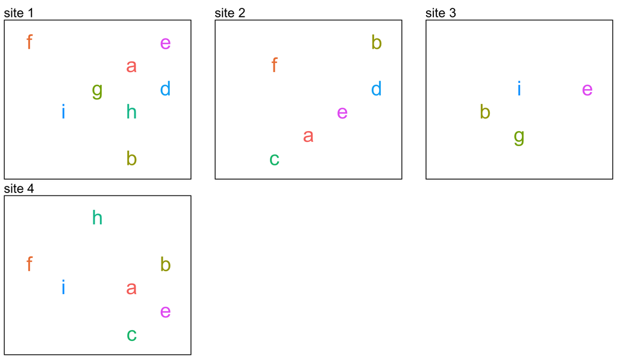

s1, s2s1, s3s1, s4s2, s3s2, s4s3, s4

Here is the complete table of pairwise results (highest-beta pair(s) highlighted):

| Site pair | Mean alpha | Gamma | Beta |
| --- | --- | --- | --- |
| s1, s2 | 7.0 | 9 | 1.29 |
| s1, s3 | 6.0 | 8 | 1.33 |
| s1, s4 | 7.5 | 9 | 1.20 |
| s2, s3 | 5.0 | 8 | 1.60 |
| s2, s4 | 6.5 | 8 | 1.23 |
| s3, s4 | 5.5 | 8 | 1.45 |

The maximum pairwise beta diversity is **1.6**, found for the pair(s): **s2, s3**.

**How to build this table:**

For each pair of sites (e.g., s1 & s2):

1. Count the species in each site: $\alpha_A$ and $\alpha_B$. Compute $\overline{\alpha} = (\alpha_A + \alpha_B) \div 2$.
2. List all unique species across both sites in the pair to get $\gamma$.
3. Compute $\beta = \gamma \div \overline{\alpha}$, rounded to two digits.

The pair with the highest $\beta$ has the most compositional distinctiveness — the most unique species relative to its average per-site richness.

**A field ecologist studying habitat complementarity wants to identify which pair of sites shows the greatest turnover in species composition (highest beta diversity). Which pair or pairs of sites (set of two) has the highest beta diversity?** Two or more pairs may share the highest value.

Unlike earlier questions where you calculated a single beta across all sites, here you calculate beta diversity separately for *each possible pair*. For each pair, use only those two sites to compute gamma and mean alpha — not all four sites together.

*You may not need to evaluate all pairs.* Pairs where the two sites share most of their species will have low beta; pairs where the two sites have very different species compositions will have high beta. Remember: $\beta = \gamma \div \overline{\alpha}$, and high $\beta$ results from high $\gamma$ and low $\overline{\alpha}$.

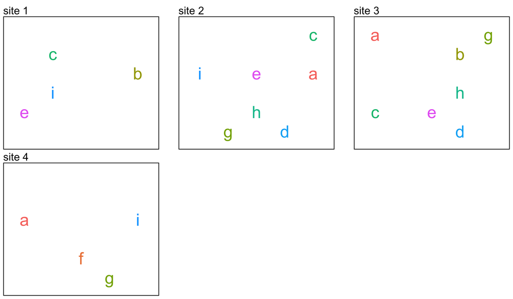

s1, s2s1, s3s1, s4s2, s3s2, s4s3, s4

Here is the complete table of pairwise results (highest-beta pair(s) highlighted):

| Site pair | Mean alpha | Gamma | Beta |
| --- | --- | --- | --- |
| s1, s2 | 5.5 | 8 | 1.45 |
| s1, s3 | 5.5 | 8 | 1.45 |
| s1, s4 | 4.0 | 7 | 1.75 |
| s2, s3 | 7.0 | 8 | 1.14 |
| s2, s4 | 5.5 | 8 | 1.45 |
| s3, s4 | 5.5 | 9 | 1.64 |

The maximum pairwise beta diversity is **1.75**, found for the pair(s): **s1, s4**.

**How to build this table:**

For each pair of sites (e.g., s1 & s2):

1. Count the species in each site: $\alpha_A$ and $\alpha_B$. Compute $\overline{\alpha} = (\alpha_A + \alpha_B) \div 2$.
2. List all unique species across both sites in the pair to get $\gamma$.
3. Compute $\beta = \gamma \div \overline{\alpha}$, rounded to two digits.

The pair with the highest $\beta$ has the most compositional distinctiveness — the most unique species relative to its average per-site richness.

**A field ecologist studying habitat complementarity wants to identify which pair of sites shows the greatest turnover in species composition (highest beta diversity). Which pair or pairs of sites (set of two) has the highest beta diversity?** Two or more pairs may share the highest value.

Unlike earlier questions where you calculated a single beta across all sites, here you calculate beta diversity separately for *each possible pair*. For each pair, use only those two sites to compute gamma and mean alpha — not all four sites together.

*You may not need to evaluate all pairs.* Pairs where the two sites share most of their species will have low beta; pairs where the two sites have very different species compositions will have high beta. Remember: $\beta = \gamma \div \overline{\alpha}$, and high $\beta$ results from high $\gamma$ and low $\overline{\alpha}$.

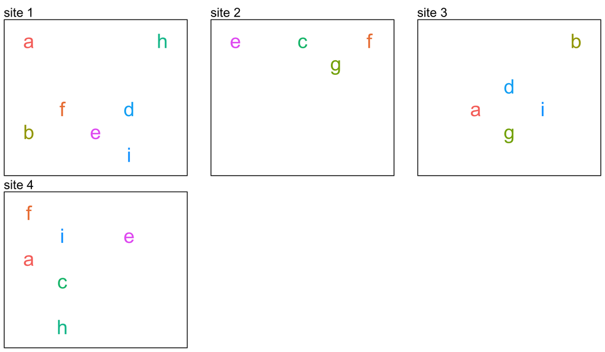

s1, s2s1, s3s1, s4s2, s3s2, s4s3, s4

Here is the complete table of pairwise results (highest-beta pair(s) highlighted):

| Site pair | Mean alpha | Gamma | Beta |
| --- | --- | --- | --- |
| s1, s2 | 5.5 | 9 | 1.64 |
| s1, s3 | 6.0 | 8 | 1.33 |
| s1, s4 | 6.5 | 8 | 1.23 |
| s2, s3 | 4.5 | 8 | 1.78 |
| s2, s4 | 5.0 | 7 | 1.40 |
| s3, s4 | 5.5 | 9 | 1.64 |

The maximum pairwise beta diversity is **1.78**, found for the pair(s): **s2, s3**.

**How to build this table:**

For each pair of sites (e.g., s1 & s2):

1. Count the species in each site: $\alpha_A$ and $\alpha_B$. Compute $\overline{\alpha} = (\alpha_A + \alpha_B) \div 2$.
2. List all unique species across both sites in the pair to get $\gamma$.
3. Compute $\beta = \gamma \div \overline{\alpha}$, rounded to two digits.

The pair with the highest $\beta$ has the most compositional distinctiveness — the most unique species relative to its average per-site richness.

**A field ecologist studying habitat complementarity wants to identify which pair of sites shows the greatest turnover in species composition (highest beta diversity). Which pair or pairs of sites (set of two) has the highest beta diversity?** Two or more pairs may share the highest value.

Unlike earlier questions where you calculated a single beta across all sites, here you calculate beta diversity separately for *each possible pair*. For each pair, use only those two sites to compute gamma and mean alpha — not all four sites together.

*You may not need to evaluate all pairs.* Pairs where the two sites share most of their species will have low beta; pairs where the two sites have very different species compositions will have high beta. Remember: $\beta = \gamma \div \overline{\alpha}$, and high $\beta$ results from high $\gamma$ and low $\overline{\alpha}$.

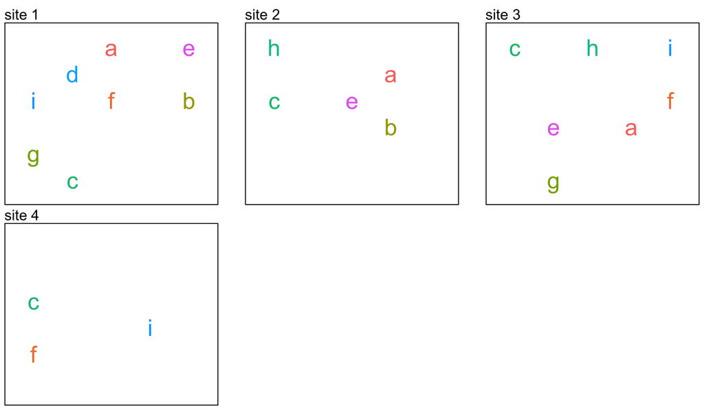

s1, s2s1, s3s1, s4s2, s3s2, s4s3, s4

Here is the complete table of pairwise results (highest-beta pair(s) highlighted):

| Site pair | Mean alpha | Gamma | Beta |
| --- | --- | --- | --- |
| s1, s2 | 6.5 | 9 | 1.38 |
| s1, s3 | 7.5 | 9 | 1.20 |
| s1, s4 | 5.5 | 8 | 1.45 |
| s2, s3 | 6.0 | 8 | 1.33 |
| s2, s4 | 4.0 | 7 | 1.75 |
| s3, s4 | 5.0 | 7 | 1.40 |

The maximum pairwise beta diversity is **1.75**, found for the pair(s): **s2, s4**.

**How to build this table:**

For each pair of sites (e.g., s1 & s2):

1. Count the species in each site: $\alpha_A$ and $\alpha_B$. Compute $\overline{\alpha} = (\alpha_A + \alpha_B) \div 2$.
2. List all unique species across both sites in the pair to get $\gamma$.
3. Compute $\beta = \gamma \div \overline{\alpha}$, rounded to two digits.

The pair with the highest $\beta$ has the most compositional distinctiveness — the most unique species relative to its average per-site richness.

**Which site or sites have *roughly* the highest species evenness?** The diagrams below show communities from five rocky intertidal zones sampled along a coastline. Each letter represents an individual organism belonging to a particular species, and each species is represented by one letter.

Evenness refers to how uniformly individuals are distributed across species. **Maximum evenness** means every species has exactly the same number of individuals; **minimum evenness** means one species heavily dominates. You do *not* need to calculate a formula here — evaluate the diagrams visually.

Sites will either be **clearly more even** (roughly equal letter frequencies) or **clearly less even** (one letter appears far more than others). Select **all** sites with the highest approximate evenness. Note that species richness may vary slightly between sites; focus on the evenness of the distribution, not the richness.

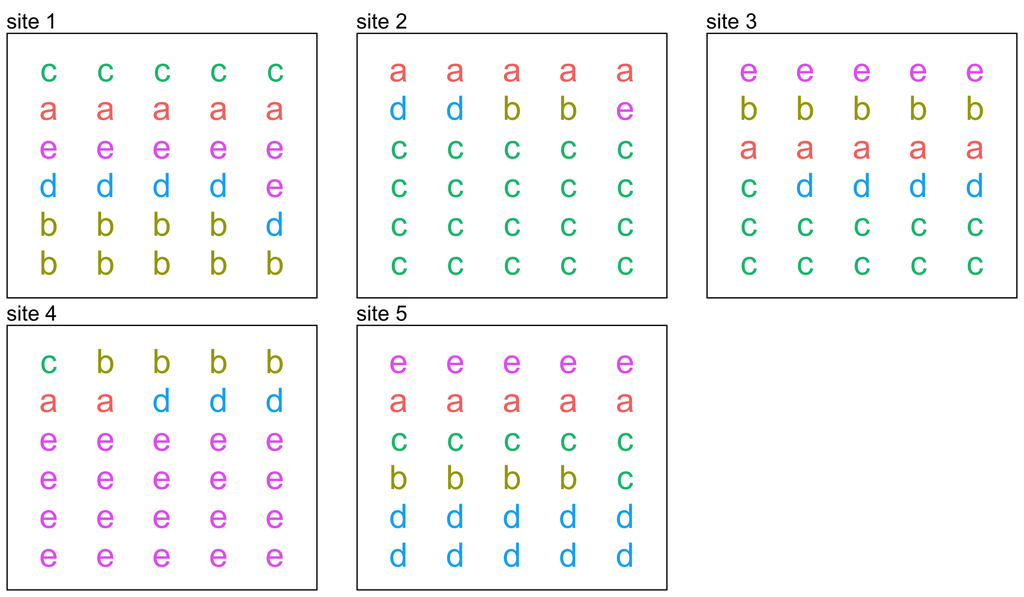

s1s2s3s4s5

The site(s) with the highest evenness is/are: **site(s) 1, 5, 3**. The remaining site(s) show clear dominance by one species.

**How to identify evenness visually:** In a highly even community, each letter (species) appears approximately the same number of times — no single species stands out. In an uneven community, one letter clearly appears far more often than any other.

The contrast between even and uneven communities in this problem is large enough that you should be able to distinguish them by eye. Sites that are even will look similar to one another; uneven sites will look clearly dominated.

**Which site or sites have *roughly* the highest species evenness?** The diagrams below show communities from five rocky intertidal zones sampled along a coastline. Each letter represents an individual organism belonging to a particular species, and each species is represented by one letter.

Evenness refers to how uniformly individuals are distributed across species. **Maximum evenness** means every species has exactly the same number of individuals; **minimum evenness** means one species heavily dominates. You do *not* need to calculate a formula here — evaluate the diagrams visually.

Sites will either be **clearly more even** (roughly equal letter frequencies) or **clearly less even** (one letter appears far more than others). Select **all** sites with the highest approximate evenness. Note that species richness may vary slightly between sites; focus on the evenness of the distribution, not the richness.

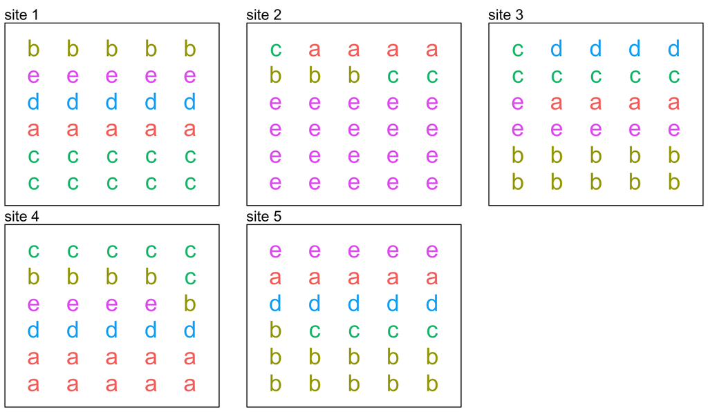

s1s2s3s4s5

The site(s) with the highest evenness is/are: **site(s) 3, 1, 5, 4**. The remaining site(s) show clear dominance by one species.

**How to identify evenness visually:** In a highly even community, each letter (species) appears approximately the same number of times — no single species stands out. In an uneven community, one letter clearly appears far more often than any other.

The contrast between even and uneven communities in this problem is large enough that you should be able to distinguish them by eye. Sites that are even will look similar to one another; uneven sites will look clearly dominated.

**Which site or sites have *roughly* the highest species evenness?** The diagrams below show communities from five rocky intertidal zones sampled along a coastline. Each letter represents an individual organism belonging to a particular species, and each species is represented by one letter.

Evenness refers to how uniformly individuals are distributed across species. **Maximum evenness** means every species has exactly the same number of individuals; **minimum evenness** means one species heavily dominates. You do *not* need to calculate a formula here — evaluate the diagrams visually.

Sites will either be **clearly more even** (roughly equal letter frequencies) or **clearly less even** (one letter appears far more than others). Select **all** sites with the highest approximate evenness. Note that species richness may vary slightly between sites; focus on the evenness of the distribution, not the richness.

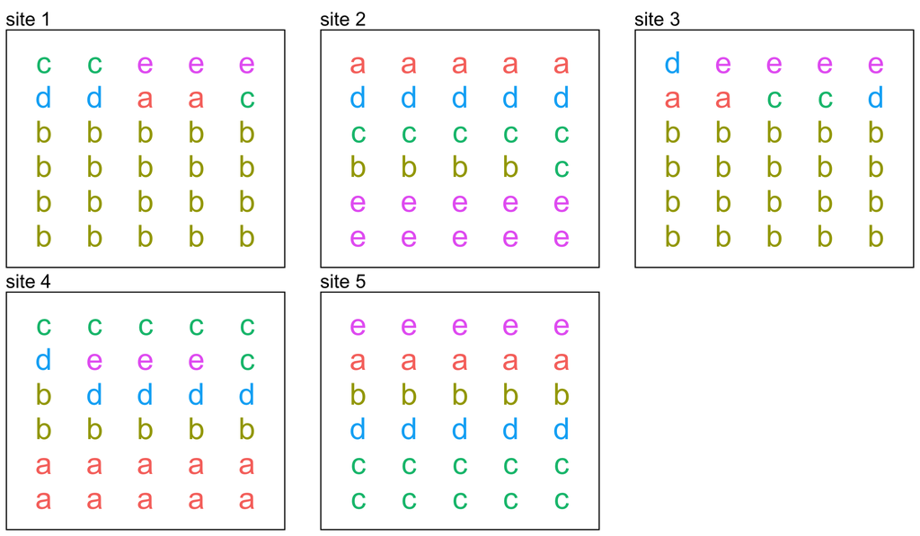

s1s2s3s4s5

The site(s) with the highest evenness is/are: **site(s) 4, 2, 5**. The remaining site(s) show clear dominance by one species.

**How to identify evenness visually:** In a highly even community, each letter (species) appears approximately the same number of times — no single species stands out. In an uneven community, one letter clearly appears far more often than any other.

The contrast between even and uneven communities in this problem is large enough that you should be able to distinguish them by eye. Sites that are even will look similar to one another; uneven sites will look clearly dominated.

**Which site or sites have *roughly* the highest species evenness?** The diagrams below show communities from five rocky intertidal zones sampled along a coastline. Each letter represents an individual organism belonging to a particular species, and each species is represented by one letter.

Evenness refers to how uniformly individuals are distributed across species. **Maximum evenness** means every species has exactly the same number of individuals; **minimum evenness** means one species heavily dominates. You do *not* need to calculate a formula here — evaluate the diagrams visually.

Sites will either be **clearly more even** (roughly equal letter frequencies) or **clearly less even** (one letter appears far more than others). Select **all** sites with the highest approximate evenness. Note that species richness may vary slightly between sites; focus on the evenness of the distribution, not the richness.

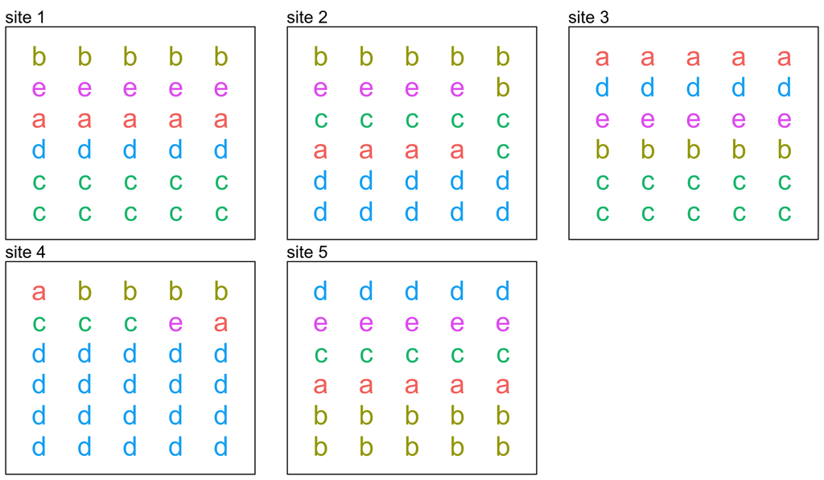

s1s2s3s4s5

The site(s) with the highest evenness is/are: **site(s) 5, 1, 3, 2**. The remaining site(s) show clear dominance by one species.

**How to identify evenness visually:** In a highly even community, each letter (species) appears approximately the same number of times — no single species stands out. In an uneven community, one letter clearly appears far more often than any other.

The contrast between even and uneven communities in this problem is large enough that you should be able to distinguish them by eye. Sites that are even will look similar to one another; uneven sites will look clearly dominated.

**Which site or sites have *roughly* the highest species evenness?** The diagrams below show communities from five rocky intertidal zones sampled along a coastline. Each letter represents an individual organism belonging to a particular species, and each species is represented by one letter.

Evenness refers to how uniformly individuals are distributed across species. **Maximum evenness** means every species has exactly the same number of individuals; **minimum evenness** means one species heavily dominates. You do *not* need to calculate a formula here — evaluate the diagrams visually.

Sites will either be **clearly more even** (roughly equal letter frequencies) or **clearly less even** (one letter appears far more than others). Select **all** sites with the highest approximate evenness. Note that species richness may vary slightly between sites; focus on the evenness of the distribution, not the richness.

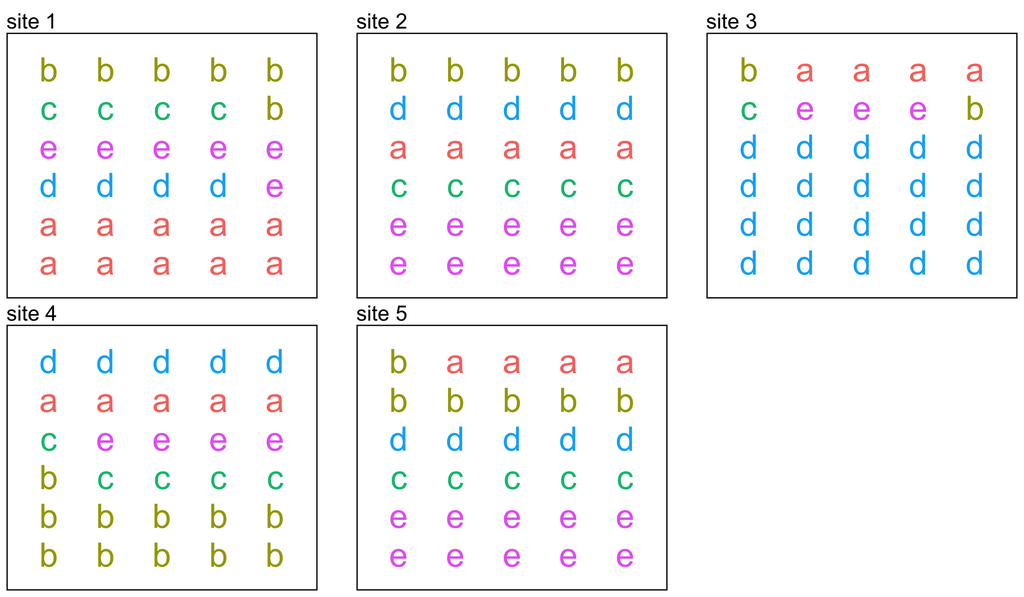

s1s2s3s4s5

The site(s) with the highest evenness is/are: **site(s) 4, 5, 2, 1**. The remaining site(s) show clear dominance by one species.

**How to identify evenness visually:** In a highly even community, each letter (species) appears approximately the same number of times — no single species stands out. In an uneven community, one letter clearly appears far more often than any other.

The contrast between even and uneven communities in this problem is large enough that you should be able to distinguish them by eye. Sites that are even will look similar to one another; uneven sites will look clearly dominated.

**Which site or sites have *roughly* the highest species evenness?** The diagrams below show communities from five rocky intertidal zones sampled along a coastline. Each letter represents an individual organism belonging to a particular species, and each species is represented by one letter.

Evenness refers to how uniformly individuals are distributed across species. **Maximum evenness** means every species has exactly the same number of individuals; **minimum evenness** means one species heavily dominates. You do *not* need to calculate a formula here — evaluate the diagrams visually.

Sites will either be **clearly more even** (roughly equal letter frequencies) or **clearly less even** (one letter appears far more than others). Select **all** sites with the highest approximate evenness. Note that species richness may vary slightly between sites; focus on the evenness of the distribution, not the richness.

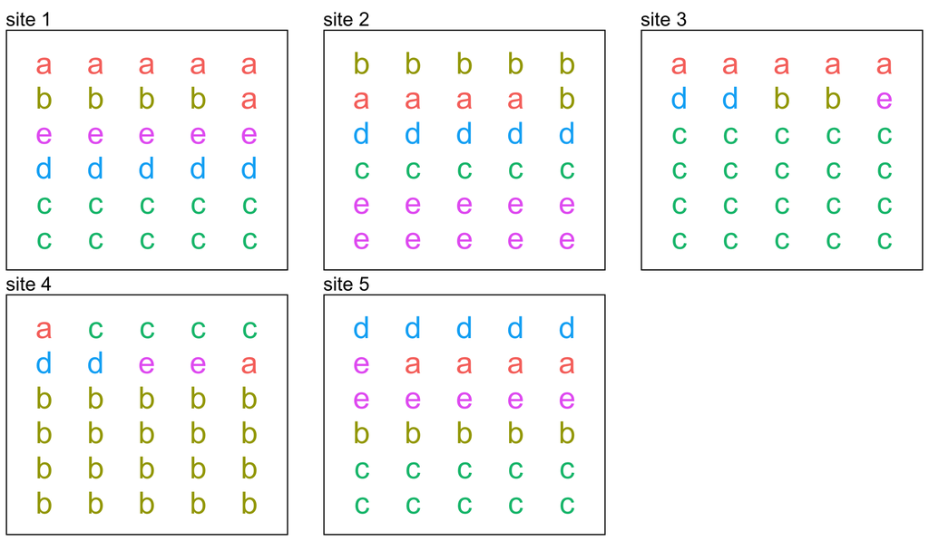

s1s2s3s4s5

The site(s) with the highest evenness is/are: **site(s) 2, 1, 5**. The remaining site(s) show clear dominance by one species.

**How to identify evenness visually:** In a highly even community, each letter (species) appears approximately the same number of times — no single species stands out. In an uneven community, one letter clearly appears far more often than any other.

The contrast between even and uneven communities in this problem is large enough that you should be able to distinguish them by eye. Sites that are even will look similar to one another; uneven sites will look clearly dominated.

**Which site or sites have *roughly* the highest species evenness?** The diagrams below show communities from five rocky intertidal zones sampled along a coastline. Each letter represents an individual organism belonging to a particular species, and each species is represented by one letter.

Evenness refers to how uniformly individuals are distributed across species. **Maximum evenness** means every species has exactly the same number of individuals; **minimum evenness** means one species heavily dominates. You do *not* need to calculate a formula here — evaluate the diagrams visually.

Sites will either be **clearly more even** (roughly equal letter frequencies) or **clearly less even** (one letter appears far more than others). Select **all** sites with the highest approximate evenness. Note that species richness may vary slightly between sites; focus on the evenness of the distribution, not the richness.

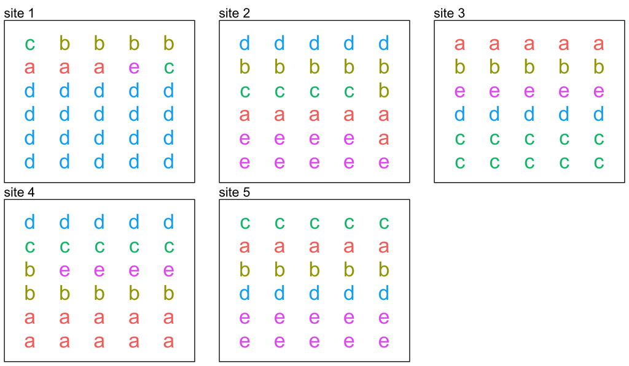

s1s2s3s4s5

The site(s) with the highest evenness is/are: **site(s) 2, 4, 5, 3**. The remaining site(s) show clear dominance by one species.

**How to identify evenness visually:** In a highly even community, each letter (species) appears approximately the same number of times — no single species stands out. In an uneven community, one letter clearly appears far more often than any other.

The contrast between even and uneven communities in this problem is large enough that you should be able to distinguish them by eye. Sites that are even will look similar to one another; uneven sites will look clearly dominated.

**Which site or sites have *roughly* the highest species evenness?** The diagrams below represent understory plant communities in five old-growth forest plots. Each letter represents an individual plant belonging to a particular species.

Evenness describes how uniformly distributed individuals are among species. **Select all** sites that show the highest approximate evenness. Sites will be either **clearly more even** (similar numbers of individuals across species) or **clearly less even** (one species numerically dominates). You do not need to apply a formula — use visual inspection. Note that species richness (number of distinct species) may vary slightly between sites; focus on the distribution of individuals, not the count of species.

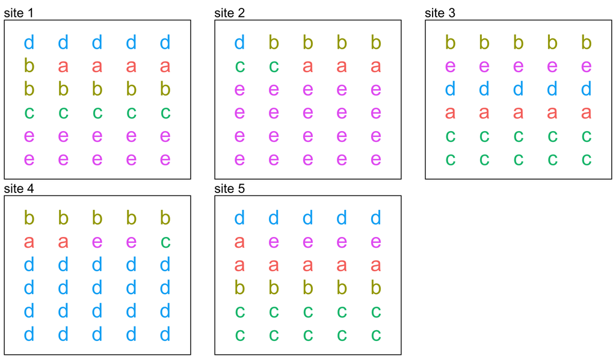

s1s2s3s4s5

The site(s) with the highest evenness is/are: **site(s) 3, 5, 1**. The remaining site(s) are clearly dominated by one species.

**How to identify this visually:** Even communities show roughly equal frequencies of each letter. Uneven communities have one letter appearing far more often than any other. The difference between even and uneven communities in this problem is deliberately large and should be apparent from inspection.

**Which site or sites have *roughly* the highest species evenness?** The diagrams below represent understory plant communities in five old-growth forest plots. Each letter represents an individual plant belonging to a particular species.

Evenness describes how uniformly distributed individuals are among species. **Select all** sites that show the highest approximate evenness. Sites will be either **clearly more even** (similar numbers of individuals across species) or **clearly less even** (one species numerically dominates). You do not need to apply a formula — use visual inspection. Note that species richness (number of distinct species) may vary slightly between sites; focus on the distribution of individuals, not the count of species.

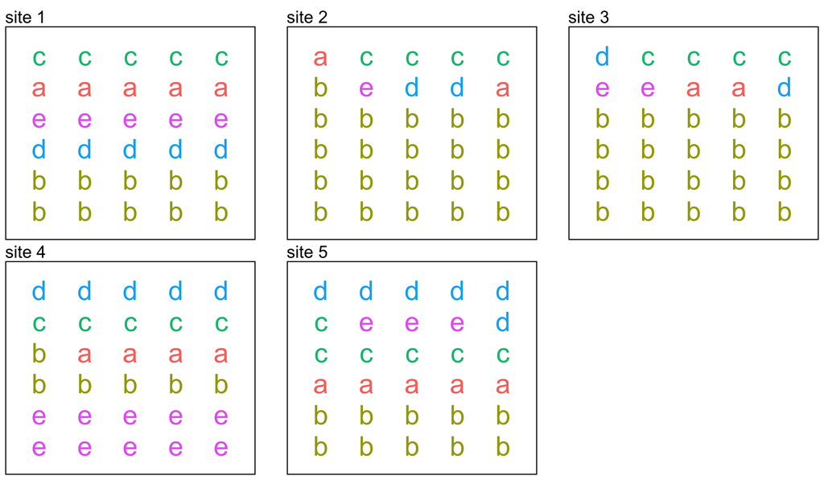

s1s2s3s4s5

The site(s) with the highest evenness is/are: **site(s) 1, 5, 4**. The remaining site(s) are clearly dominated by one species.

**How to identify this visually:** Even communities show roughly equal frequencies of each letter. Uneven communities have one letter appearing far more often than any other. The difference between even and uneven communities in this problem is deliberately large and should be apparent from inspection.

**Which site or sites have *roughly* the highest species evenness?** The diagrams below represent understory plant communities in five old-growth forest plots. Each letter represents an individual plant belonging to a particular species.

Evenness describes how uniformly distributed individuals are among species. **Select all** sites that show the highest approximate evenness. Sites will be either **clearly more even** (similar numbers of individuals across species) or **clearly less even** (one species numerically dominates). You do not need to apply a formula — use visual inspection. Note that species richness (number of distinct species) may vary slightly between sites; focus on the distribution of individuals, not the count of species.

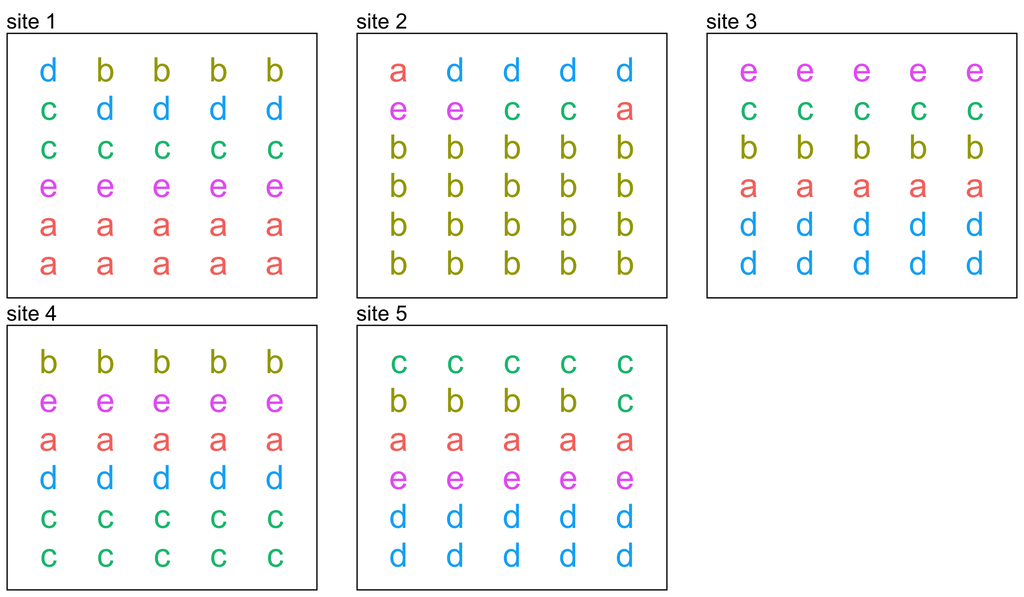

s1s2s3s4s5

The site(s) with the highest evenness is/are: **site(s) 5, 1, 4, 3**. The remaining site(s) are clearly dominated by one species.

**How to identify this visually:** Even communities show roughly equal frequencies of each letter. Uneven communities have one letter appearing far more often than any other. The difference between even and uneven communities in this problem is deliberately large and should be apparent from inspection.

**Which site or sites have *roughly* the highest species evenness?** The diagrams below represent understory plant communities in five old-growth forest plots. Each letter represents an individual plant belonging to a particular species.

Evenness describes how uniformly distributed individuals are among species. **Select all** sites that show the highest approximate evenness. Sites will be either **clearly more even** (similar numbers of individuals across species) or **clearly less even** (one species numerically dominates). You do not need to apply a formula — use visual inspection. Note that species richness (number of distinct species) may vary slightly between sites; focus on the distribution of individuals, not the count of species.

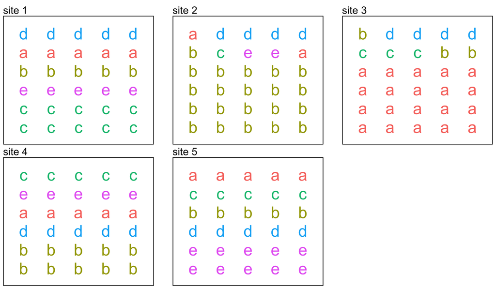

s1s2s3s4s5

The site(s) with the highest evenness is/are: **site(s) 5, 4, 1**. The remaining site(s) are clearly dominated by one species.

**How to identify this visually:** Even communities show roughly equal frequencies of each letter. Uneven communities have one letter appearing far more often than any other. The difference between even and uneven communities in this problem is deliberately large and should be apparent from inspection.

**Which site or sites have *roughly* the highest species evenness?** The diagrams below represent understory plant communities in five old-growth forest plots. Each letter represents an individual plant belonging to a particular species.

Evenness describes how uniformly distributed individuals are among species. **Select all** sites that show the highest approximate evenness. Sites will be either **clearly more even** (similar numbers of individuals across species) or **clearly less even** (one species numerically dominates). You do not need to apply a formula — use visual inspection. Note that species richness (number of distinct species) may vary slightly between sites; focus on the distribution of individuals, not the count of species.

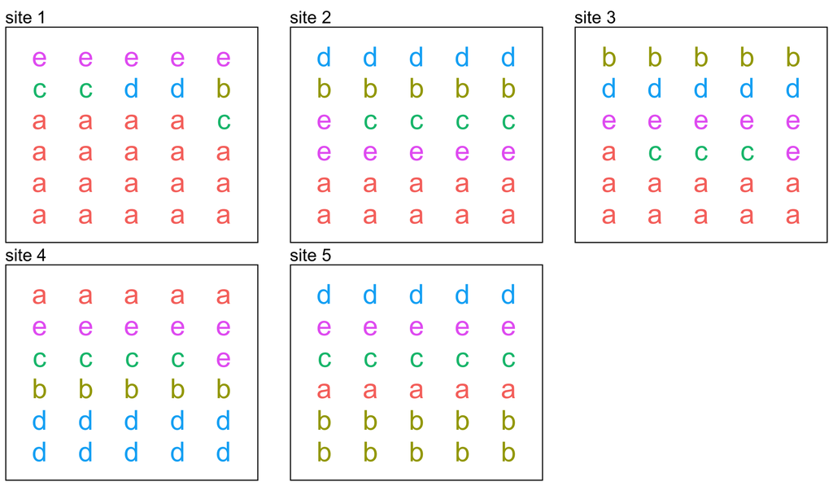

s1s2s3s4s5

The site(s) with the highest evenness is/are: **site(s) 2, 4, 3, 5**. The remaining site(s) are clearly dominated by one species.

**How to identify this visually:** Even communities show roughly equal frequencies of each letter. Uneven communities have one letter appearing far more often than any other. The difference between even and uneven communities in this problem is deliberately large and should be apparent from inspection.

**Which site or sites have *roughly* the highest species evenness?** The diagrams below represent understory plant communities in five old-growth forest plots. Each letter represents an individual plant belonging to a particular species.

Evenness describes how uniformly distributed individuals are among species. **Select all** sites that show the highest approximate evenness. Sites will be either **clearly more even** (similar numbers of individuals across species) or **clearly less even** (one species numerically dominates). You do not need to apply a formula — use visual inspection. Note that species richness (number of distinct species) may vary slightly between sites; focus on the distribution of individuals, not the count of species.

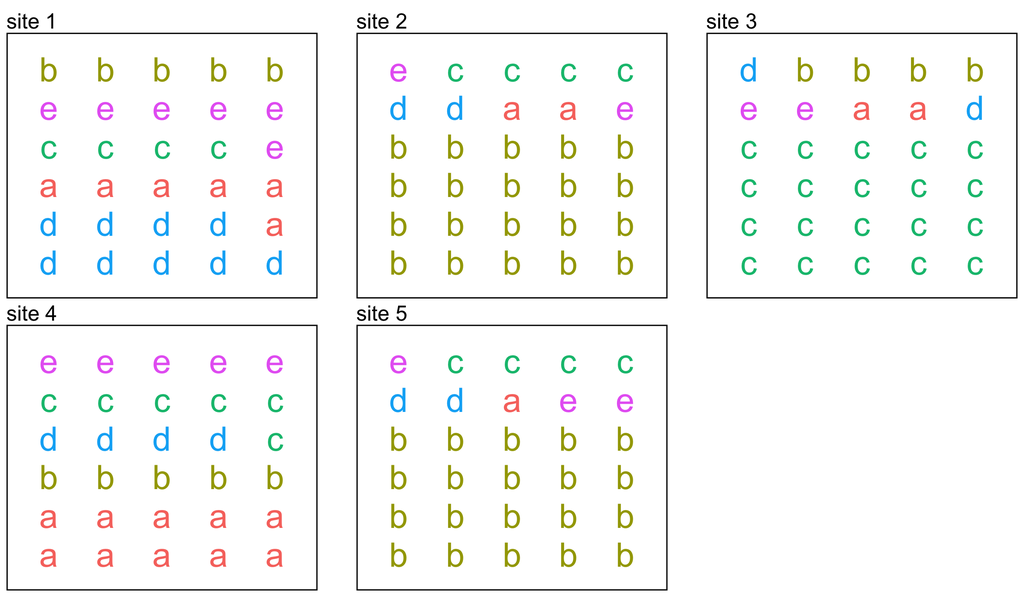

s1s2s3s4s5

The site(s) with the highest evenness is/are: **site(s) 4, 1**. The remaining site(s) are clearly dominated by one species.

**How to identify this visually:** Even communities show roughly equal frequencies of each letter. Uneven communities have one letter appearing far more often than any other. The difference between even and uneven communities in this problem is deliberately large and should be apparent from inspection.

**Which site or sites have *roughly* the highest species evenness?** The diagrams below represent understory plant communities in five old-growth forest plots. Each letter represents an individual plant belonging to a particular species.

Evenness describes how uniformly distributed individuals are among species. **Select all** sites that show the highest approximate evenness. Sites will be either **clearly more even** (similar numbers of individuals across species) or **clearly less even** (one species numerically dominates). You do not need to apply a formula — use visual inspection. Note that species richness (number of distinct species) may vary slightly between sites; focus on the distribution of individuals, not the count of species.

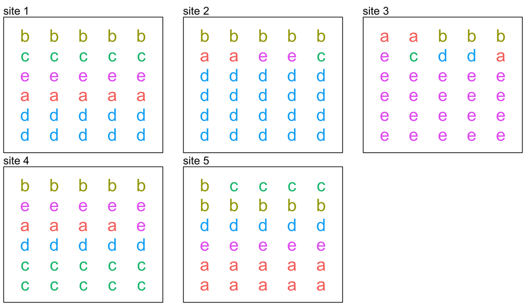

s1s2s3s4s5

The site(s) with the highest evenness is/are: **site(s) 5, 1, 4**. The remaining site(s) are clearly dominated by one species.

**How to identify this visually:** Even communities show roughly equal frequencies of each letter. Uneven communities have one letter appearing far more often than any other. The difference between even and uneven communities in this problem is deliberately large and should be apparent from inspection.

**Calculate the evenness (Pielou's $J$) of a bird community** surveyed in a tropical rainforest plot, given that its Shannon diversity $H$ = 2.623 and its log species richness $ln(S)$ = 3.497.

The three diversity components are related by:

$$H = ln(S) \times J$$

Rearranging by dividing both sides by $ln(S)$:

$$J = H \div ln(S)$$

**Round your answer to two decimal places.**

Substitute the given values into the rearranged formula:

$$J = H \div ln(S) = 2.623 \div 3.497 =
0.75$$

**$J =$ 0.75**

**What this means:** Pielou's $J$ ranges from 0 (completely uneven: a single species has all individuals) to 1 (perfectly even: all species equally abundant). A value of 0.75 indicates that this community is at 75% of maximum evenness.

**Common mistake:** Do not confuse $J$ (evenness) with $H$ (Shannon diversity) or $ln(S)$ (log richness). $J$ is the ratio of $H$ to the maximum possible diversity given $S$ species, which equals $ln(S)$.

Enter only the numeric value (e.g., 0.75) without any additional text for it to register as correct.

**Calculate the evenness (Pielou's $J$) of a bird community** surveyed in a tropical rainforest plot, given that its Shannon diversity $H$ = 0.817 and its log species richness $ln(S)$ = 3.714.

The three diversity components are related by:

$$H = ln(S) \times J$$

Rearranging by dividing both sides by $ln(S)$:

$$J = H \div ln(S)$$

**Round your answer to two decimal places.**

Substitute the given values into the rearranged formula:

$$J = H \div ln(S) = 0.817 \div 3.714 =
0.22$$

**$J =$ 0.22**

**What this means:** Pielou's $J$ ranges from 0 (completely uneven: a single species has all individuals) to 1 (perfectly even: all species equally abundant). A value of 0.22 indicates that this community is at 22% of maximum evenness.

**Common mistake:** Do not confuse $J$ (evenness) with $H$ (Shannon diversity) or $ln(S)$ (log richness). $J$ is the ratio of $H$ to the maximum possible diversity given $S$ species, which equals $ln(S)$.

Enter only the numeric value (e.g., 0.22) without any additional text for it to register as correct.

**Calculate the evenness (Pielou's $J$) of a bird community** surveyed in a tropical rainforest plot, given that its Shannon diversity $H$ = 0.416 and its log species richness $ln(S)$ = 3.784.

The three diversity components are related by:

$$H = ln(S) \times J$$

Rearranging by dividing both sides by $ln(S)$:

$$J = H \div ln(S)$$

**Round your answer to two decimal places.**

Substitute the given values into the rearranged formula:

$$J = H \div ln(S) = 0.416 \div 3.784 =
0.11$$

**$J =$ 0.11**

**What this means:** Pielou's $J$ ranges from 0 (completely uneven: a single species has all individuals) to 1 (perfectly even: all species equally abundant). A value of 0.11 indicates that this community is at 11% of maximum evenness.

**Common mistake:** Do not confuse $J$ (evenness) with $H$ (Shannon diversity) or $ln(S)$ (log richness). $J$ is the ratio of $H$ to the maximum possible diversity given $S$ species, which equals $ln(S)$.

Enter only the numeric value (e.g., 0.11) without any additional text for it to register as correct.

**Calculate the evenness (Pielou's $J$) of a bird community** surveyed in a tropical rainforest plot, given that its Shannon diversity $H$ = 1.95 and its log species richness $ln(S)$ = 3.611.

The three diversity components are related by:

$$H = ln(S) \times J$$

Rearranging by dividing both sides by $ln(S)$:

$$J = H \div ln(S)$$

**Round your answer to two decimal places.**

Substitute the given values into the rearranged formula:

$$J = H \div ln(S) = 1.95 \div 3.611 =
0.54$$

**$J =$ 0.54**

**What this means:** Pielou's $J$ ranges from 0 (completely uneven: a single species has all individuals) to 1 (perfectly even: all species equally abundant). A value of 0.54 indicates that this community is at 54% of maximum evenness.

**Common mistake:** Do not confuse $J$ (evenness) with $H$ (Shannon diversity) or $ln(S)$ (log richness). $J$ is the ratio of $H$ to the maximum possible diversity given $S$ species, which equals $ln(S)$.

Enter only the numeric value (e.g., 0.54) without any additional text for it to register as correct.

**Calculate the evenness (Pielou's $J$) of a bird community** surveyed in a tropical rainforest plot, given that its Shannon diversity $H$ = 2.695 and its log species richness $ln(S)$ = 3.85.

The three diversity components are related by:

$$H = ln(S) \times J$$

Rearranging by dividing both sides by $ln(S)$:

$$J = H \div ln(S)$$

**Round your answer to two decimal places.**

Substitute the given values into the rearranged formula:

$$J = H \div ln(S) = 2.695 \div 3.85 =
0.7$$

**$J =$ 0.7**

**What this means:** Pielou's $J$ ranges from 0 (completely uneven: a single species has all individuals) to 1 (perfectly even: all species equally abundant). A value of 0.7 indicates that this community is at 70% of maximum evenness.

**Common mistake:** Do not confuse $J$ (evenness) with $H$ (Shannon diversity) or $ln(S)$ (log richness). $J$ is the ratio of $H$ to the maximum possible diversity given $S$ species, which equals $ln(S)$.

Enter only the numeric value (e.g., 0.7) without any additional text for it to register as correct.

**Calculate the evenness (Pielou's $J$) of a bird community** surveyed in a tropical rainforest plot, given that its Shannon diversity $H$ = 3.462 and its log species richness $ln(S)$ = 3.497.

The three diversity components are related by:

$$H = ln(S) \times J$$

Rearranging by dividing both sides by $ln(S)$:

$$J = H \div ln(S)$$

**Round your answer to two decimal places.**

Substitute the given values into the rearranged formula:

$$J = H \div ln(S) = 3.462 \div 3.497 =
0.99$$

**$J =$ 0.99**

**What this means:** Pielou's $J$ ranges from 0 (completely uneven: a single species has all individuals) to 1 (perfectly even: all species equally abundant). A value of 0.99 indicates that this community is at 99% of maximum evenness.

**Common mistake:** Do not confuse $J$ (evenness) with $H$ (Shannon diversity) or $ln(S)$ (log richness). $J$ is the ratio of $H$ to the maximum possible diversity given $S$ species, which equals $ln(S)$.

Enter only the numeric value (e.g., 0.99) without any additional text for it to register as correct.

**Calculate the evenness (Pielou's $J$) of a bird community** surveyed in a tropical rainforest plot, given that its Shannon diversity $H$ = 3.327 and its log species richness $ln(S)$ = 3.738.

The three diversity components are related by:

$$H = ln(S) \times J$$

Rearranging by dividing both sides by $ln(S)$:

$$J = H \div ln(S)$$

**Round your answer to two decimal places.**

Substitute the given values into the rearranged formula:

$$J = H \div ln(S) = 3.327 \div 3.738 =
0.89$$

**$J =$ 0.89**

**What this means:** Pielou's $J$ ranges from 0 (completely uneven: a single species has all individuals) to 1 (perfectly even: all species equally abundant). A value of 0.89 indicates that this community is at 89% of maximum evenness.

**Common mistake:** Do not confuse $J$ (evenness) with $H$ (Shannon diversity) or $ln(S)$ (log richness). $J$ is the ratio of $H$ to the maximum possible diversity given $S$ species, which equals $ln(S)$.

Enter only the numeric value (e.g., 0.89) without any additional text for it to register as correct.

**Calculate the log species richness, $ln(S)$, of a marine benthic community** sampled from the seafloor, given that its Shannon diversity $H$ = 3.476 and its evenness (Pielou's $J$) = 0.93.

The three diversity components are related by:

$$H = ln(S) \times J$$

Rearranging by dividing both sides by $J$:

$$ln(S) = H \div J$$

Note: because you are solving for $ln(S)$ — the *logarithm* of species richness — you do **not** need to take any logarithms yourself. The formula already gives you $ln(S)$ directly. **Round your answer to two decimal places.**

Substitute the given values:

$$ln(S) = H \div J = 3.476 \div 0.93 =
3.74$$

**$ln(S) =$ 3.74**

**Key insight:** The equation $H = ln(S) \times J$ links three quantities. Given any two, you can find the third by simple algebra: - To find $J$: divide $H$ by $ln(S)$ - To find $ln(S)$: divide $H$ by $J$ ← **this problem** - To find $H$: multiply $ln(S)$ by $J$

Enter only the numeric value **3.74** for it to register as correct.

**Calculate the log species richness, $ln(S)$, of a marine benthic community** sampled from the seafloor, given that its Shannon diversity $H$ = 0.665 and its evenness (Pielou's $J$) = 0.17.

The three diversity components are related by:

$$H = ln(S) \times J$$

Rearranging by dividing both sides by $J$:

$$ln(S) = H \div J$$

Note: because you are solving for $ln(S)$ — the *logarithm* of species richness — you do **not** need to take any logarithms yourself. The formula already gives you $ln(S)$ directly. **Round your answer to two decimal places.**

Substitute the given values:

$$ln(S) = H \div J = 0.665 \div 0.17 =
3.91$$

**$ln(S) =$ 3.91**

**Key insight:** The equation $H = ln(S) \times J$ links three quantities. Given any two, you can find the third by simple algebra: - To find $J$: divide $H$ by $ln(S)$ - To find $ln(S)$: divide $H$ by $J$ ← **this problem** - To find $H$: multiply $ln(S)$ by $J$

Enter only the numeric value **3.91** for it to register as correct.

**Calculate the log species richness, $ln(S)$, of a marine benthic community** sampled from the seafloor, given that its Shannon diversity $H$ = 1.975 and its evenness (Pielou's $J$) = 0.56.

The three diversity components are related by:

$$H = ln(S) \times J$$

Rearranging by dividing both sides by $J$:

$$ln(S) = H \div J$$

Note: because you are solving for $ln(S)$ — the *logarithm* of species richness — you do **not** need to take any logarithms yourself. The formula already gives you $ln(S)$ directly. **Round your answer to two decimal places.**

Substitute the given values:

$$ln(S) = H \div J = 1.975 \div 0.56 =
3.53$$

**$ln(S) =$ 3.53**

**Key insight:** The equation $H = ln(S) \times J$ links three quantities. Given any two, you can find the third by simple algebra: - To find $J$: divide $H$ by $ln(S)$ - To find $ln(S)$: divide $H$ by $J$ ← **this problem** - To find $H$: multiply $ln(S)$ by $J$

Enter only the numeric value **3.53** for it to register as correct.

**Calculate the log species richness, $ln(S)$, of a marine benthic community** sampled from the seafloor, given that its Shannon diversity $H$ = 3.189 and its evenness (Pielou's $J$) = 0.89.

The three diversity components are related by:

$$H = ln(S) \times J$$

Rearranging by dividing both sides by $J$:

$$ln(S) = H \div J$$

Note: because you are solving for $ln(S)$ — the *logarithm* of species richness — you do **not** need to take any logarithms yourself. The formula already gives you $ln(S)$ directly. **Round your answer to two decimal places.**

Substitute the given values:

$$ln(S) = H \div J = 3.189 \div 0.89 =
3.58$$

**$ln(S) =$ 3.58**

**Key insight:** The equation $H = ln(S) \times J$ links three quantities. Given any two, you can find the third by simple algebra: - To find $J$: divide $H$ by $ln(S)$ - To find $ln(S)$: divide $H$ by $J$ ← **this problem** - To find $H$: multiply $ln(S)$ by $J$

Enter only the numeric value **3.58** for it to register as correct.

**Calculate the log species richness, $ln(S)$, of a marine benthic community** sampled from the seafloor, given that its Shannon diversity $H$ = 0.353 and its evenness (Pielou's $J$) = 0.1.

The three diversity components are related by:

$$H = ln(S) \times J$$

Rearranging by dividing both sides by $J$:

$$ln(S) = H \div J$$

Note: because you are solving for $ln(S)$ — the *logarithm* of species richness — you do **not** need to take any logarithms yourself. The formula already gives you $ln(S)$ directly. **Round your answer to two decimal places.**

Substitute the given values:

$$ln(S) = H \div J = 0.353 \div 0.1 =
3.53$$

**$ln(S) =$ 3.53**

**Key insight:** The equation $H = ln(S) \times J$ links three quantities. Given any two, you can find the third by simple algebra: - To find $J$: divide $H$ by $ln(S)$ - To find $ln(S)$: divide $H$ by $J$ ← **this problem** - To find $H$: multiply $ln(S)$ by $J$

Enter only the numeric value **3.53** for it to register as correct.

**Calculate the log species richness, $ln(S)$, of a marine benthic community** sampled from the seafloor, given that its Shannon diversity $H$ = 0.858 and its evenness (Pielou's $J$) = 0.25.

The three diversity components are related by:

$$H = ln(S) \times J$$

Rearranging by dividing both sides by $J$:

$$ln(S) = H \div J$$

Note: because you are solving for $ln(S)$ — the *logarithm* of species richness — you do **not** need to take any logarithms yourself. The formula already gives you $ln(S)$ directly. **Round your answer to two decimal places.**

Substitute the given values:

$$ln(S) = H \div J = 0.858 \div 0.25 =
3.43$$

**$ln(S) =$ 3.43**

**Key insight:** The equation $H = ln(S) \times J$ links three quantities. Given any two, you can find the third by simple algebra: - To find $J$: divide $H$ by $ln(S)$ - To find $ln(S)$: divide $H$ by $J$ ← **this problem** - To find $H$: multiply $ln(S)$ by $J$

Enter only the numeric value **3.43** for it to register as correct.

**Calculate the log species richness, $ln(S)$, of a marine benthic community** sampled from the seafloor, given that its Shannon diversity $H$ = 3.675 and its evenness (Pielou's $J$) = 0.96.

The three diversity components are related by:

$$H = ln(S) \times J$$

Rearranging by dividing both sides by $J$:

$$ln(S) = H \div J$$

Note: because you are solving for $ln(S)$ — the *logarithm* of species richness — you do **not** need to take any logarithms yourself. The formula already gives you $ln(S)$ directly. **Round your answer to two decimal places.**

Substitute the given values:

$$ln(S) = H \div J = 3.675 \div 0.96 =
3.83$$

**$ln(S) =$ 3.83**

**Key insight:** The equation $H = ln(S) \times J$ links three quantities. Given any two, you can find the third by simple algebra: - To find $J$: divide $H$ by $ln(S)$ - To find $ln(S)$: divide $H$ by $J$ ← **this problem** - To find $H$: multiply $ln(S)$ by $J$

Enter only the numeric value **3.83** for it to register as correct.

**Which site or set of sites in the table below has the highest species richness?** The data are from five savanna plots. The variables are: $H$ = Shannon diversity, $ln(S)$ = log species richness, $J$ = Pielou's evenness, related by:

$$H = ln(S) \times J \quad \Rightarrow
\quad ln(S) = H \div J$$

The table below shows $H$ and $J$ for each site. To determine which site has the highest species richness, you need to calculate $ln(S)$ for each site. Because the logarithm is a monotonically increasing function, the site with the **highest $ln(S)$** also has the **highest $S$** — so you do *not* need to convert back to $S$.

**Select *all* sites with the highest approximate value of $ln(S)$.**

| Site | J | H |
| --- | --- | --- |
| 1 | 0.11 | 0.345 |
| 2 | 0.61 | 1.342 |
| 3 | 0.65 | 1.495 |
| 4 | 0.39 | 1.486 |
| 5 | 0.14 | 0.405 |

site 1site 2site 3site 4site 5

For each site, calculate $ln(S) = H \div J$. The full table (with calculated $ln(S)$ and $S$ shown, and highest-richness sites highlighted) is:

| Site | J | H | ln(S) | S |
| --- | --- | --- | --- | --- |
| 1 | 0.11 | 0.345 | 3.14 | 23 |
| 2 | 0.61 | 1.342 | 2.20 | 9 |
| 3 | 0.65 | 1.495 | 2.30 | 10 |
| 4 | 0.39 | 1.486 | 3.81 | 45 |
| 5 | 0.14 | 0.405 | 2.89 | 18 |

The site(s) with the highest species richness is/are: **site(s) 4**.

**How to work through this:** Create a new column in the table by dividing each site's $H$ by its $J$. The site(s) with the largest resulting $ln(S)$ value have the highest species richness. Note that $ln(S)$ values that are close to one another (within ~0.25) should be treated as approximately equal.

A spreadsheet (e.g., Google Sheets) makes these calculations quick, but a calculator works fine too. You do **not** need to exponentiate $ln(S)$ back to $S$ to answer this question.

**Which site or set of sites in the table below has the highest species richness?** The data are from five savanna plots. The variables are: $H$ = Shannon diversity, $ln(S)$ = log species richness, $J$ = Pielou's evenness, related by:

$$H = ln(S) \times J \quad \Rightarrow
\quad ln(S) = H \div J$$

The table below shows $H$ and $J$ for each site. To determine which site has the highest species richness, you need to calculate $ln(S)$ for each site. Because the logarithm is a monotonically increasing function, the site with the **highest $ln(S)$** also has the **highest $S$** — so you do *not* need to convert back to $S$.

**Select *all* sites with the highest approximate value of $ln(S)$.**

| Site | J | H |
| --- | --- | --- |
| 1 | 0.11 | 0.421 |
| 2 | 0.59 | 1.900 |
| 3 | 0.37 | 1.088 |
| 4 | 0.21 | 0.804 |
| 5 | 0.39 | 1.494 |

site 1site 2site 3site 4site 5

For each site, calculate $ln(S) = H \div J$. The full table (with calculated $ln(S)$ and $S$ shown, and highest-richness sites highlighted) is:

| Site | J | H | ln(S) | S |
| --- | --- | --- | --- | --- |
| 1 | 0.11 | 0.421 | 3.83 | 46 |
| 2 | 0.59 | 1.900 | 3.22 | 25 |
| 3 | 0.37 | 1.088 | 2.94 | 19 |
| 4 | 0.21 | 0.804 | 3.83 | 46 |
| 5 | 0.39 | 1.494 | 3.83 | 46 |

The site(s) with the highest species richness is/are: **site(s) 1, 4, 5**.

**How to work through this:** Create a new column in the table by dividing each site's $H$ by its $J$. The site(s) with the largest resulting $ln(S)$ value have the highest species richness. Note that $ln(S)$ values that are close to one another (within ~0.25) should be treated as approximately equal.

A spreadsheet (e.g., Google Sheets) makes these calculations quick, but a calculator works fine too. You do **not** need to exponentiate $ln(S)$ back to $S$ to answer this question.

**Which site or set of sites in the table below has the highest species richness?** The data are from five savanna plots. The variables are: $H$ = Shannon diversity, $ln(S)$ = log species richness, $J$ = Pielou's evenness, related by:

$$H = ln(S) \times J \quad \Rightarrow
\quad ln(S) = H \div J$$

The table below shows $H$ and $J$ for each site. To determine which site has the highest species richness, you need to calculate $ln(S)$ for each site. Because the logarithm is a monotonically increasing function, the site with the **highest $ln(S)$** also has the **highest $S$** — so you do *not* need to convert back to $S$.

**Select *all* sites with the highest approximate value of $ln(S)$.**

| Site | J | H |
| --- | --- | --- |
| 1 | 0.82 | 2.370 |
| 2 | 0.32 | 1.056 |
| 3 | 0.19 | 0.735 |
| 4 | 0.25 | 0.750 |
| 5 | 0.73 | 2.219 |

site 1site 2site 3site 4site 5

For each site, calculate $ln(S) = H \div J$. The full table (with calculated $ln(S)$ and $S$ shown, and highest-richness sites highlighted) is:

| Site | J | H | ln(S) | S |
| --- | --- | --- | --- | --- |
| 1 | 0.82 | 2.370 | 2.89 | 18 |
| 2 | 0.32 | 1.056 | 3.30 | 27 |
| 3 | 0.19 | 0.735 | 3.87 | 48 |
| 4 | 0.25 | 0.750 | 3.00 | 20 |
| 5 | 0.73 | 2.219 | 3.04 | 21 |

The site(s) with the highest species richness is/are: **site(s) 3**.

**How to work through this:** Create a new column in the table by dividing each site's $H$ by its $J$. The site(s) with the largest resulting $ln(S)$ value have the highest species richness. Note that $ln(S)$ values that are close to one another (within ~0.25) should be treated as approximately equal.

A spreadsheet (e.g., Google Sheets) makes these calculations quick, but a calculator works fine too. You do **not** need to exponentiate $ln(S)$ back to $S$ to answer this question.

**Which site or set of sites in the table below has the highest species richness?** The data are from five savanna plots. The variables are: $H$ = Shannon diversity, $ln(S)$ = log species richness, $J$ = Pielou's evenness, related by:

$$H = ln(S) \times J \quad \Rightarrow
\quad ln(S) = H \div J$$

The table below shows $H$ and $J$ for each site. To determine which site has the highest species richness, you need to calculate $ln(S)$ for each site. Because the logarithm is a monotonically increasing function, the site with the **highest $ln(S)$** also has the **highest $S$** — so you do *not* need to convert back to $S$.

**Select *all* sites with the highest approximate value of $ln(S)$.**

| Site | J | H |
| --- | --- | --- |
| 1 | 0.26 | 0.816 |
| 2 | 0.16 | 0.602 |
| 3 | 0.36 | 1.112 |
| 4 | 0.31 | 1.166 |
| 5 | 0.31 | 1.166 |

site 1site 2site 3site 4site 5

For each site, calculate $ln(S) = H \div J$. The full table (with calculated $ln(S)$ and $S$ shown, and highest-richness sites highlighted) is:

| Site | J | H | ln(S) | S |
| --- | --- | --- | --- | --- |
| 1 | 0.26 | 0.816 | 3.14 | 23 |
| 2 | 0.16 | 0.602 | 3.76 | 43 |
| 3 | 0.36 | 1.112 | 3.09 | 22 |
| 4 | 0.31 | 1.166 | 3.76 | 43 |
| 5 | 0.31 | 1.166 | 3.76 | 43 |

The site(s) with the highest species richness is/are: **site(s) 2, 4, 5**.

**How to work through this:** Create a new column in the table by dividing each site's $H$ by its $J$. The site(s) with the largest resulting $ln(S)$ value have the highest species richness. Note that $ln(S)$ values that are close to one another (within ~0.25) should be treated as approximately equal.

A spreadsheet (e.g., Google Sheets) makes these calculations quick, but a calculator works fine too. You do **not** need to exponentiate $ln(S)$ back to $S$ to answer this question.

**Which site or set of sites in the table below has the highest species richness?** The data are from five savanna plots. The variables are: $H$ = Shannon diversity, $ln(S)$ = log species richness, $J$ = Pielou's evenness, related by:

$$H = ln(S) \times J \quad \Rightarrow
\quad ln(S) = H \div J$$

The table below shows $H$ and $J$ for each site. To determine which site has the highest species richness, you need to calculate $ln(S)$ for each site. Because the logarithm is a monotonically increasing function, the site with the **highest $ln(S)$** also has the **highest $S$** — so you do *not* need to convert back to $S$.

**Select *all* sites with the highest approximate value of $ln(S)$.**

| Site | J | H |
| --- | --- | --- |
| 1 | 0.21 | 0.699 |
| 2 | 0.32 | 1.245 |
| 3 | 0.50 | 1.385 |
| 4 | 0.43 | 1.367 |
| 5 | 0.39 | 1.517 |

site 1site 2site 3site 4site 5

For each site, calculate $ln(S) = H \div J$. The full table (with calculated $ln(S)$ and $S$ shown, and highest-richness sites highlighted) is:

| Site | J | H | ln(S) | S |
| --- | --- | --- | --- | --- |
| 1 | 0.21 | 0.699 | 3.33 | 28 |
| 2 | 0.32 | 1.245 | 3.89 | 49 |
| 3 | 0.50 | 1.385 | 2.77 | 16 |
| 4 | 0.43 | 1.367 | 3.18 | 24 |
| 5 | 0.39 | 1.517 | 3.89 | 49 |

The site(s) with the highest species richness is/are: **site(s) 2, 5**.

**How to work through this:** Create a new column in the table by dividing each site's $H$ by its $J$. The site(s) with the largest resulting $ln(S)$ value have the highest species richness. Note that $ln(S)$ values that are close to one another (within ~0.25) should be treated as approximately equal.

A spreadsheet (e.g., Google Sheets) makes these calculations quick, but a calculator works fine too. You do **not** need to exponentiate $ln(S)$ back to $S$ to answer this question.

**Which site or set of sites in the table below has the highest species richness?** The data are from five savanna plots. The variables are: $H$ = Shannon diversity, $ln(S)$ = log species richness, $J$ = Pielou's evenness, related by:

$$H = ln(S) \times J \quad \Rightarrow
\quad ln(S) = H \div J$$

The table below shows $H$ and $J$ for each site. To determine which site has the highest species richness, you need to calculate $ln(S)$ for each site. Because the logarithm is a monotonically increasing function, the site with the **highest $ln(S)$** also has the **highest $S$** — so you do *not* need to convert back to $S$.

**Select *all* sites with the highest approximate value of $ln(S)$.**

| Site | J | H |
| --- | --- | --- |
| 1 | 0.38 | 1.429 |
| 2 | 0.39 | 1.466 |
| 3 | 0.80 | 2.400 |
| 4 | 0.11 | 0.414 |
| 5 | 0.87 | 2.558 |

site 1site 2site 3site 4site 5

For each site, calculate $ln(S) = H \div J$. The full table (with calculated $ln(S)$ and $S$ shown, and highest-richness sites highlighted) is:

| Site | J | H | ln(S) | S |
| --- | --- | --- | --- | --- |
| 1 | 0.38 | 1.429 | 3.76 | 43 |
| 2 | 0.39 | 1.466 | 3.76 | 43 |
| 3 | 0.80 | 2.400 | 3.00 | 20 |
| 4 | 0.11 | 0.414 | 3.76 | 43 |
| 5 | 0.87 | 2.558 | 2.94 | 19 |

The site(s) with the highest species richness is/are: **site(s) 1, 2, 4**.

**How to work through this:** Create a new column in the table by dividing each site's $H$ by its $J$. The site(s) with the largest resulting $ln(S)$ value have the highest species richness. Note that $ln(S)$ values that are close to one another (within ~0.25) should be treated as approximately equal.

A spreadsheet (e.g., Google Sheets) makes these calculations quick, but a calculator works fine too. You do **not** need to exponentiate $ln(S)$ back to $S$ to answer this question.

**Which site or set of sites in the table below has the highest species richness?** The data are from five savanna plots. The variables are: $H$ = Shannon diversity, $ln(S)$ = log species richness, $J$ = Pielou's evenness, related by:

$$H = ln(S) \times J \quad \Rightarrow
\quad ln(S) = H \div J$$

The table below shows $H$ and $J$ for each site. To determine which site has the highest species richness, you need to calculate $ln(S)$ for each site. Because the logarithm is a monotonically increasing function, the site with the **highest $ln(S)$** also has the **highest $S$** — so you do *not* need to convert back to $S$.

**Select *all* sites with the highest approximate value of $ln(S)$.**

| Site | J | H |
| --- | --- | --- |
| 1 | 0.33 | 1.247 |
| 2 | 0.11 | 0.359 |
| 3 | 0.12 | 0.454 |
| 4 | 0.40 | 1.084 |
| 5 | 0.25 | 0.945 |

site 1site 2site 3site 4site 5

For each site, calculate $ln(S) = H \div J$. The full table (with calculated $ln(S)$ and $S$ shown, and highest-richness sites highlighted) is:

| Site | J | H | ln(S) | S |
| --- | --- | --- | --- | --- |
| 1 | 0.33 | 1.247 | 3.78 | 44 |
| 2 | 0.11 | 0.359 | 3.26 | 26 |
| 3 | 0.12 | 0.454 | 3.78 | 44 |
| 4 | 0.40 | 1.084 | 2.71 | 15 |
| 5 | 0.25 | 0.945 | 3.78 | 44 |

The site(s) with the highest species richness is/are: **site(s) 1, 3, 5**.

**How to work through this:** Create a new column in the table by dividing each site's $H$ by its $J$. The site(s) with the largest resulting $ln(S)$ value have the highest species richness. Note that $ln(S)$ values that are close to one another (within ~0.25) should be treated as approximately equal.

A spreadsheet (e.g., Google Sheets) makes these calculations quick, but a calculator works fine too. You do **not** need to exponentiate $ln(S)$ back to $S$ to answer this question.

**Which site or set of sites has the highest evenness (Pielou's $J$)?** The data are from five mangrove forest plots. The variables are: $H$ = Shannon diversity, $ln(S)$ = log species richness, $J$ = Pielou's evenness, $S$ = species richness, related by:

$$H = ln(S) \times J \quad \Rightarrow
\quad J = H \div ln(S)$$

The table shows $S$, $ln(S)$, and $H$ for each site. Calculate $J$ for each site to determine which has the highest evenness. $S$ is shown for reference only and is not needed for the calculation.

**Select *all* sites with the highest Pielou's $J$.**

| Site | S | ln(S) | H |
| --- | --- | --- | --- |
| 1 | 52 | 3.95 | 2.963 |
| 2 | 23 | 3.14 | 2.355 |
| 3 | 60 | 4.09 | 2.004 |
| 4 | 22 | 3.09 | 1.514 |
| 5 | 4 | 1.39 | 0.681 |

site 1site 2site 3site 4site 5

For each site, calculate $J = H \div ln(S)$. The full table with calculated $J$ values (highest-evenness sites highlighted) is:

| Site | S | ln(S) | H | J |
| --- | --- | --- | --- | --- |
| 1 | 52 | 3.95 | 2.963 | 0.75 |
| 2 | 23 | 3.14 | 2.355 | 0.75 |
| 3 | 60 | 4.09 | 2.004 | 0.49 |
| 4 | 22 | 3.09 | 1.514 | 0.49 |
| 5 | 4 | 1.39 | 0.681 | 0.49 |

The site(s) with the highest evenness is/are: **site(s) 1, 2**.

**How to work through this:** Divide each site's $H$ by its $ln(S)$ to get $J$. The site(s) with the largest $J$ value are the most even. A spreadsheet makes this convenient, but a calculator also works. You can use the provided $S$ column to sanity-check your results (higher $S$ generally means higher $ln(S)$, all else equal), but $S$ is not needed in the calculation itself.

**Which site or set of sites has the highest evenness (Pielou's $J$)?** The data are from five mangrove forest plots. The variables are: $H$ = Shannon diversity, $ln(S)$ = log species richness, $J$ = Pielou's evenness, $S$ = species richness, related by:

$$H = ln(S) \times J \quad \Rightarrow
\quad J = H \div ln(S)$$

The table shows $S$, $ln(S)$, and $H$ for each site. Calculate $J$ for each site to determine which has the highest evenness. $S$ is shown for reference only and is not needed for the calculation.

**Select *all* sites with the highest Pielou's $J$.**

| Site | S | ln(S) | H |
| --- | --- | --- | --- |
| 1 | 35 | 3.56 | 0.712 |
| 2 | 52 | 3.95 | 3.081 |
| 3 | 51 | 3.93 | 3.065 |
| 4 | 24 | 3.18 | 2.480 |
| 5 | 18 | 2.89 | 2.254 |

site 1site 2site 3site 4site 5

For each site, calculate $J = H \div ln(S)$. The full table with calculated $J$ values (highest-evenness sites highlighted) is:

| Site | S | ln(S) | H | J |
| --- | --- | --- | --- | --- |
| 1 | 35 | 3.56 | 0.712 | 0.20 |
| 2 | 52 | 3.95 | 3.081 | 0.78 |
| 3 | 51 | 3.93 | 3.065 | 0.78 |
| 4 | 24 | 3.18 | 2.480 | 0.78 |
| 5 | 18 | 2.89 | 2.254 | 0.78 |

The site(s) with the highest evenness is/are: **site(s) 2, 3, 4, 5**.

**How to work through this:** Divide each site's $H$ by its $ln(S)$ to get $J$. The site(s) with the largest $J$ value are the most even. A spreadsheet makes this convenient, but a calculator also works. You can use the provided $S$ column to sanity-check your results (higher $S$ generally means higher $ln(S)$, all else equal), but $S$ is not needed in the calculation itself.

**Which site or set of sites has the highest evenness (Pielou's $J$)?** The data are from five mangrove forest plots. The variables are: $H$ = Shannon diversity, $ln(S)$ = log species richness, $J$ = Pielou's evenness, $S$ = species richness, related by:

$$H = ln(S) \times J \quad \Rightarrow
\quad J = H \div ln(S)$$

The table shows $S$, $ln(S)$, and $H$ for each site. Calculate $J$ for each site to determine which has the highest evenness. $S$ is shown for reference only and is not needed for the calculation.

**Select *all* sites with the highest Pielou's $J$.**

| Site | S | ln(S) | H |
| --- | --- | --- | --- |
| 1 | 21 | 3.04 | 0.790 |
| 2 | 28 | 3.33 | 2.864 |
| 3 | 20 | 3.00 | 0.780 |
| 4 | 47 | 3.85 | 3.311 |
| 5 | 70 | 4.25 | 1.105 |

site 1site 2site 3site 4site 5

For each site, calculate $J = H \div ln(S)$. The full table with calculated $J$ values (highest-evenness sites highlighted) is:

| Site | S | ln(S) | H | J |
| --- | --- | --- | --- | --- |
| 1 | 21 | 3.04 | 0.790 | 0.26 |
| 2 | 28 | 3.33 | 2.864 | 0.86 |
| 3 | 20 | 3.00 | 0.780 | 0.26 |
| 4 | 47 | 3.85 | 3.311 | 0.86 |
| 5 | 70 | 4.25 | 1.105 | 0.26 |

The site(s) with the highest evenness is/are: **site(s) 2, 4**.

**How to work through this:** Divide each site's $H$ by its $ln(S)$ to get $J$. The site(s) with the largest $J$ value are the most even. A spreadsheet makes this convenient, but a calculator also works. You can use the provided $S$ column to sanity-check your results (higher $S$ generally means higher $ln(S)$, all else equal), but $S$ is not needed in the calculation itself.

**Which site or set of sites has the highest evenness (Pielou's $J$)?** The data are from five mangrove forest plots. The variables are: $H$ = Shannon diversity, $ln(S)$ = log species richness, $J$ = Pielou's evenness, $S$ = species richness, related by:

$$H = ln(S) \times J \quad \Rightarrow
\quad J = H \div ln(S)$$

The table shows $S$, $ln(S)$, and $H$ for each site. Calculate $J$ for each site to determine which has the highest evenness. $S$ is shown for reference only and is not needed for the calculation.

**Select *all* sites with the highest Pielou's $J$.**

| Site | S | ln(S) | H |
| --- | --- | --- | --- |
| 1 | 39 | 3.66 | 1.574 |
| 2 | 43 | 3.76 | 3.234 |
| 3 | 23 | 3.14 | 2.700 |
| 4 | 53 | 3.97 | 3.414 |
| 5 | 27 | 3.30 | 1.419 |

site 1site 2site 3site 4site 5

For each site, calculate $J = H \div ln(S)$. The full table with calculated $J$ values (highest-evenness sites highlighted) is:

| Site | S | ln(S) | H | J |
| --- | --- | --- | --- | --- |
| 1 | 39 | 3.66 | 1.574 | 0.43 |
| 2 | 43 | 3.76 | 3.234 | 0.86 |
| 3 | 23 | 3.14 | 2.700 | 0.86 |
| 4 | 53 | 3.97 | 3.414 | 0.86 |
| 5 | 27 | 3.30 | 1.419 | 0.43 |

The site(s) with the highest evenness is/are: **site(s) 2, 3, 4**.

**How to work through this:** Divide each site's $H$ by its $ln(S)$ to get $J$. The site(s) with the largest $J$ value are the most even. A spreadsheet makes this convenient, but a calculator also works. You can use the provided $S$ column to sanity-check your results (higher $S$ generally means higher $ln(S)$, all else equal), but $S$ is not needed in the calculation itself.

**Which site or set of sites has the highest evenness (Pielou's $J$)?** The data are from five mangrove forest plots. The variables are: $H$ = Shannon diversity, $ln(S)$ = log species richness, $J$ = Pielou's evenness, $S$ = species richness, related by:

$$H = ln(S) \times J \quad \Rightarrow
\quad J = H \div ln(S)$$

The table shows $S$, $ln(S)$, and $H$ for each site. Calculate $J$ for each site to determine which has the highest evenness. $S$ is shown for reference only and is not needed for the calculation.

**Select *all* sites with the highest Pielou's $J$.**

| Site | S | ln(S) | H |
| --- | --- | --- | --- |
| 1 | 68 | 4.22 | 3.249 |
| 2 | 24 | 3.18 | 0.318 |
| 3 | 5 | 1.61 | 1.240 |
| 4 | 42 | 3.74 | 2.880 |
| 5 | 40 | 3.69 | 0.369 |

site 1site 2site 3site 4site 5

For each site, calculate $J = H \div ln(S)$. The full table with calculated $J$ values (highest-evenness sites highlighted) is:

| Site | S | ln(S) | H | J |
| --- | --- | --- | --- | --- |
| 1 | 68 | 4.22 | 3.249 | 0.77 |
| 2 | 24 | 3.18 | 0.318 | 0.10 |
| 3 | 5 | 1.61 | 1.240 | 0.77 |
| 4 | 42 | 3.74 | 2.880 | 0.77 |
| 5 | 40 | 3.69 | 0.369 | 0.10 |

The site(s) with the highest evenness is/are: **site(s) 1, 3, 4**.

**How to work through this:** Divide each site's $H$ by its $ln(S)$ to get $J$. The site(s) with the largest $J$ value are the most even. A spreadsheet makes this convenient, but a calculator also works. You can use the provided $S$ column to sanity-check your results (higher $S$ generally means higher $ln(S)$, all else equal), but $S$ is not needed in the calculation itself.

**Which site or set of sites has the highest evenness (Pielou's $J$)?** The data are from five mangrove forest plots. The variables are: $H$ = Shannon diversity, $ln(S)$ = log species richness, $J$ = Pielou's evenness, $S$ = species richness, related by:

$$H = ln(S) \times J \quad \Rightarrow
\quad J = H \div ln(S)$$

The table shows $S$, $ln(S)$, and $H$ for each site. Calculate $J$ for each site to determine which has the highest evenness. $S$ is shown for reference only and is not needed for the calculation.

**Select *all* sites with the highest Pielou's $J$.**

| Site | S | ln(S) | H |
| --- | --- | --- | --- |
| 1 | 37 | 3.61 | 0.433 |
| 2 | 29 | 3.37 | 2.999 |
| 3 | 25 | 3.22 | 2.866 |
| 4 | 37 | 3.61 | 3.213 |
| 5 | 52 | 3.95 | 3.516 |

site 1site 2site 3site 4site 5

For each site, calculate $J = H \div ln(S)$. The full table with calculated $J$ values (highest-evenness sites highlighted) is:

| Site | S | ln(S) | H | J |
| --- | --- | --- | --- | --- |
| 1 | 37 | 3.61 | 0.433 | 0.12 |
| 2 | 29 | 3.37 | 2.999 | 0.89 |
| 3 | 25 | 3.22 | 2.866 | 0.89 |
| 4 | 37 | 3.61 | 3.213 | 0.89 |
| 5 | 52 | 3.95 | 3.516 | 0.89 |

The site(s) with the highest evenness is/are: **site(s) 2, 3, 4, 5**.

**How to work through this:** Divide each site's $H$ by its $ln(S)$ to get $J$. The site(s) with the largest $J$ value are the most even. A spreadsheet makes this convenient, but a calculator also works. You can use the provided $S$ column to sanity-check your results (higher $S$ generally means higher $ln(S)$, all else equal), but $S$ is not needed in the calculation itself.

**Which site or set of sites has the highest evenness (Pielou's $J$)?** The data are from five mangrove forest plots. The variables are: $H$ = Shannon diversity, $ln(S)$ = log species richness, $J$ = Pielou's evenness, $S$ = species richness, related by:

$$H = ln(S) \times J \quad \Rightarrow
\quad J = H \div ln(S)$$

The table shows $S$, $ln(S)$, and $H$ for each site. Calculate $J$ for each site to determine which has the highest evenness. $S$ is shown for reference only and is not needed for the calculation.

**Select *all* sites with the highest Pielou's $J$.**

| Site | S | ln(S) | H |
| --- | --- | --- | --- |
| 1 | 27 | 3.30 | 2.739 |
| 2 | 66 | 4.19 | 1.927 |
| 3 | 58 | 4.06 | 1.868 |
| 4 | 33 | 3.50 | 1.610 |
| 5 | 33 | 3.50 | 1.610 |

site 1site 2site 3site 4site 5

For each site, calculate $J = H \div ln(S)$. The full table with calculated $J$ values (highest-evenness sites highlighted) is:

| Site | S | ln(S) | H | J |
| --- | --- | --- | --- | --- |
| 1 | 27 | 3.30 | 2.739 | 0.83 |
| 2 | 66 | 4.19 | 1.927 | 0.46 |
| 3 | 58 | 4.06 | 1.868 | 0.46 |
| 4 | 33 | 3.50 | 1.610 | 0.46 |
| 5 | 33 | 3.50 | 1.610 | 0.46 |

The site(s) with the highest evenness is/are: **site(s) 1**.

**How to work through this:** Divide each site's $H$ by its $ln(S)$ to get $J$. The site(s) with the largest $J$ value are the most even. A spreadsheet makes this convenient, but a calculator also works. You can use the provided $S$ column to sanity-check your results (higher $S$ generally means higher $ln(S)$, all else equal), but $S$ is not needed in the calculation itself.

**Is there a site or set of sites that clearly has higher species richness than all remaining sites?** The data below are from five long-term biodiversity monitoring stations. Only $H$ (Shannon diversity) is provided — $J$ (evenness) was not recorded, except that the **minimum value of $J$ in this system is 0.1** (some evenness is always present) and $J$ has a **maximum of 1** (perfect evenness). The variables are related by:

$$H = ln(S) \times J \quad \Rightarrow
\quad ln(S) = H \div J$$

If one site's minimum possible $ln(S)$ is still higher than another site's maximum possible $ln(S)$, then those sites are distinguishable in terms of richness. **Select *all* sites in the higher-richness set** if such a set exists, or select "cannot tell with information given" if no sites can be distinguished.

| Site | H |
| --- | --- |
| 1 | 1.00 |
| 2 | 1.07 |
| 3 | 1.12 |
| 4 | 1.11 |
| 5 | 1.11 |

site 1site 2site 3site 4site 5cannot tell with information given

The key is to compute, for each site, the **range of possible $ln(S)$ values** given the constraints on $J$ ($0.1 \leq J \leq 1$):

- **Maximum possible $ln(S)$:** assumes $J$ is at its minimum (0.1), so $ln(S)_{max} = H \div 0.1$
- **Minimum possible $ln(S)$:** assumes $J$ is at its maximum (1), so $ln(S)_{min} = H \div 1 = H$

| Site | H | min J | max J | min ln(S) | max ln(S) |
| --- | --- | --- | --- | --- | --- |
| 1 | 1.00 | 0.1 | 1 | 1.00 | 10.0 |
| 2 | 1.07 | 0.1 | 1 | 1.07 | 10.7 |
| 3 | 1.12 | 0.1 | 1 | 1.12 | 11.2 |
| 4 | 1.11 | 0.1 | 1 | 1.11 | 11.1 |
| 5 | 1.11 | 0.1 | 1 | 1.11 | 11.1 |

Then check: is there any site whose **minimum possible $ln(S)$** exceeds the **maximum possible $ln(S)$** of all other sites? If so, those sites are unambiguously richer. Values within ~0.25 of one another should be treated as roughly equivalent.

In this case: **there is no site whose minimum possible ln(S) is greater than the maximum possible ln(S) of any other site; the richness ranges of all sites overlap with each other**.

**Recommended approach:** Use a spreadsheet to compute the min and max $ln(S)$ columns, then compare the ranges.

**Is there a site or set of sites that clearly has higher species richness than all remaining sites?** The data below are from five long-term biodiversity monitoring stations. Only $H$ (Shannon diversity) is provided — $J$ (evenness) was not recorded, except that the **minimum value of $J$ in this system is 0.1** (some evenness is always present) and $J$ has a **maximum of 1** (perfect evenness). The variables are related by:

$$H = ln(S) \times J \quad \Rightarrow
\quad ln(S) = H \div J$$

If one site's minimum possible $ln(S)$ is still higher than another site's maximum possible $ln(S)$, then those sites are distinguishable in terms of richness. **Select *all* sites in the higher-richness set** if such a set exists, or select "cannot tell with information given" if no sites can be distinguished.

| Site | H |
| --- | --- |
| 1 | 0.02 |
| 2 | 2.11 |
| 3 | 1.92 |
| 4 | 0.03 |
| 5 | 0.17 |

site 1site 2site 3site 4site 5cannot tell with information given

The key is to compute, for each site, the **range of possible $ln(S)$ values** given the constraints on $J$ ($0.1 \leq J \leq 1$):

- **Maximum possible $ln(S)$:** assumes $J$ is at its minimum (0.1), so $ln(S)_{max} = H \div 0.1$
- **Minimum possible $ln(S)$:** assumes $J$ is at its maximum (1), so $ln(S)_{min} = H \div 1 = H$

| Site | H | min J | max J | min ln(S) | max ln(S) |
| --- | --- | --- | --- | --- | --- |
| 1 | 0.02 | 0.1 | 1 | 0.02 | 0.2 |
| 2 | 2.11 | 0.1 | 1 | 2.11 | 21.1 |
| 3 | 1.92 | 0.1 | 1 | 1.92 | 19.2 |
| 4 | 0.03 | 0.1 | 1 | 0.03 | 0.3 |
| 5 | 0.17 | 0.1 | 1 | 0.17 | 1.7 |

Then check: is there any site whose **minimum possible $ln(S)$** exceeds the **maximum possible $ln(S)$** of all other sites? If so, those sites are unambiguously richer. Values within ~0.25 of one another should be treated as roughly equivalent.

In this case: **the minimum possible ln(S) of site(s) 2, 3 is greater than the maximum possible ln(S) of the other site(s), so those sites are unambiguously higher in richness**.

**Recommended approach:** Use a spreadsheet to compute the min and max $ln(S)$ columns, then compare the ranges.

**Is there a site or set of sites that clearly has higher species richness than all remaining sites?** The data below are from five long-term biodiversity monitoring stations. Only $H$ (Shannon diversity) is provided — $J$ (evenness) was not recorded, except that the **minimum value of $J$ in this system is 0.1** (some evenness is always present) and $J$ has a **maximum of 1** (perfect evenness). The variables are related by:

$$H = ln(S) \times J \quad \Rightarrow
\quad ln(S) = H \div J$$

If one site's minimum possible $ln(S)$ is still higher than another site's maximum possible $ln(S)$, then those sites are distinguishable in terms of richness. **Select *all* sites in the higher-richness set** if such a set exists, or select "cannot tell with information given" if no sites can be distinguished.

| Site | H |
| --- | --- |
| 1 | 1.17 |
| 2 | 0.70 |
| 3 | 1.24 |
| 4 | 0.79 |
| 5 | 1.41 |

site 1site 2site 3site 4site 5cannot tell with information given

The key is to compute, for each site, the **range of possible $ln(S)$ values** given the constraints on $J$ ($0.1 \leq J \leq 1$):

- **Maximum possible $ln(S)$:** assumes $J$ is at its minimum (0.1), so $ln(S)_{max} = H \div 0.1$
- **Minimum possible $ln(S)$:** assumes $J$ is at its maximum (1), so $ln(S)_{min} = H \div 1 = H$

| Site | H | min J | max J | min ln(S) | max ln(S) |
| --- | --- | --- | --- | --- | --- |
| 1 | 1.17 | 0.1 | 1 | 1.17 | 11.7 |
| 2 | 0.70 | 0.1 | 1 | 0.70 | 7.0 |
| 3 | 1.24 | 0.1 | 1 | 1.24 | 12.4 |
| 4 | 0.79 | 0.1 | 1 | 0.79 | 7.9 |
| 5 | 1.41 | 0.1 | 1 | 1.41 | 14.1 |

Then check: is there any site whose **minimum possible $ln(S)$** exceeds the **maximum possible $ln(S)$** of all other sites? If so, those sites are unambiguously richer. Values within ~0.25 of one another should be treated as roughly equivalent.

In this case: **there is no site whose minimum possible ln(S) is greater than the maximum possible ln(S) of any other site; the richness ranges of all sites overlap with each other**.

**Recommended approach:** Use a spreadsheet to compute the min and max $ln(S)$ columns, then compare the ranges.

**Is there a site or set of sites that clearly has higher species richness than all remaining sites?** The data below are from five long-term biodiversity monitoring stations. Only $H$ (Shannon diversity) is provided — $J$ (evenness) was not recorded, except that the **minimum value of $J$ in this system is 0.1** (some evenness is always present) and $J$ has a **maximum of 1** (perfect evenness). The variables are related by:

$$H = ln(S) \times J \quad \Rightarrow
\quad ln(S) = H \div J$$

If one site's minimum possible $ln(S)$ is still higher than another site's maximum possible $ln(S)$, then those sites are distinguishable in terms of richness. **Select *all* sites in the higher-richness set** if such a set exists, or select "cannot tell with information given" if no sites can be distinguished.

| Site | H |
| --- | --- |
| 1 | 0.46 |
| 2 | 1.01 |
| 3 | 1.22 |
| 4 | 1.04 |
| 5 | 0.99 |

site 1site 2site 3site 4site 5cannot tell with information given

The key is to compute, for each site, the **range of possible $ln(S)$ values** given the constraints on $J$ ($0.1 \leq J \leq 1$):

- **Maximum possible $ln(S)$:** assumes $J$ is at its minimum (0.1), so $ln(S)_{max} = H \div 0.1$
- **Minimum possible $ln(S)$:** assumes $J$ is at its maximum (1), so $ln(S)_{min} = H \div 1 = H$

| Site | H | min J | max J | min ln(S) | max ln(S) |
| --- | --- | --- | --- | --- | --- |
| 1 | 0.46 | 0.1 | 1 | 0.46 | 4.6 |
| 2 | 1.01 | 0.1 | 1 | 1.01 | 10.1 |
| 3 | 1.22 | 0.1 | 1 | 1.22 | 12.2 |
| 4 | 1.04 | 0.1 | 1 | 1.04 | 10.4 |
| 5 | 0.99 | 0.1 | 1 | 0.99 | 9.9 |

Then check: is there any site whose **minimum possible $ln(S)$** exceeds the **maximum possible $ln(S)$** of all other sites? If so, those sites are unambiguously richer. Values within ~0.25 of one another should be treated as roughly equivalent.

In this case: **there is no site whose minimum possible ln(S) is greater than the maximum possible ln(S) of any other site; the richness ranges of all sites overlap with each other**.

**Recommended approach:** Use a spreadsheet to compute the min and max $ln(S)$ columns, then compare the ranges.

**Is there a site or set of sites that clearly has higher species richness than all remaining sites?** The data below are from five long-term biodiversity monitoring stations. Only $H$ (Shannon diversity) is provided — $J$ (evenness) was not recorded, except that the **minimum value of $J$ in this system is 0.1** (some evenness is always present) and $J$ has a **maximum of 1** (perfect evenness). The variables are related by:

$$H = ln(S) \times J \quad \Rightarrow
\quad ln(S) = H \div J$$

If one site's minimum possible $ln(S)$ is still higher than another site's maximum possible $ln(S)$, then those sites are distinguishable in terms of richness. **Select *all* sites in the higher-richness set** if such a set exists, or select "cannot tell with information given" if no sites can be distinguished.

| Site | H |
| --- | --- |
| 1 | 1.19 |
| 2 | 0.91 |
| 3 | 0.86 |
| 4 | 1.40 |
| 5 | 1.01 |

site 1site 2site 3site 4site 5cannot tell with information given

The key is to compute, for each site, the **range of possible $ln(S)$ values** given the constraints on $J$ ($0.1 \leq J \leq 1$):

- **Maximum possible $ln(S)$:** assumes $J$ is at its minimum (0.1), so $ln(S)_{max} = H \div 0.1$
- **Minimum possible $ln(S)$:** assumes $J$ is at its maximum (1), so $ln(S)_{min} = H \div 1 = H$

| Site | H | min J | max J | min ln(S) | max ln(S) |
| --- | --- | --- | --- | --- | --- |
| 1 | 1.19 | 0.1 | 1 | 1.19 | 11.9 |
| 2 | 0.91 | 0.1 | 1 | 0.91 | 9.1 |
| 3 | 0.86 | 0.1 | 1 | 0.86 | 8.6 |
| 4 | 1.40 | 0.1 | 1 | 1.40 | 14.0 |
| 5 | 1.01 | 0.1 | 1 | 1.01 | 10.1 |

Then check: is there any site whose **minimum possible $ln(S)$** exceeds the **maximum possible $ln(S)$** of all other sites? If so, those sites are unambiguously richer. Values within ~0.25 of one another should be treated as roughly equivalent.

In this case: **there is no site whose minimum possible ln(S) is greater than the maximum possible ln(S) of any other site; the richness ranges of all sites overlap with each other**.

**Recommended approach:** Use a spreadsheet to compute the min and max $ln(S)$ columns, then compare the ranges.

**Is there a site or set of sites that clearly has higher species richness than all remaining sites?** The data below are from five long-term biodiversity monitoring stations. Only $H$ (Shannon diversity) is provided — $J$ (evenness) was not recorded, except that the **minimum value of $J$ in this system is 0.1** (some evenness is always present) and $J$ has a **maximum of 1** (perfect evenness). The variables are related by:

$$H = ln(S) \times J \quad \Rightarrow
\quad ln(S) = H \div J$$

If one site's minimum possible $ln(S)$ is still higher than another site's maximum possible $ln(S)$, then those sites are distinguishable in terms of richness. **Select *all* sites in the higher-richness set** if such a set exists, or select "cannot tell with information given" if no sites can be distinguished.

| Site | H |
| --- | --- |
| 1 | 1.01 |
| 2 | 1.24 |
| 3 | 1.06 |
| 4 | 1.14 |
| 5 | 1.10 |

site 1site 2site 3site 4site 5cannot tell with information given

The key is to compute, for each site, the **range of possible $ln(S)$ values** given the constraints on $J$ ($0.1 \leq J \leq 1$):

- **Maximum possible $ln(S)$:** assumes $J$ is at its minimum (0.1), so $ln(S)_{max} = H \div 0.1$
- **Minimum possible $ln(S)$:** assumes $J$ is at its maximum (1), so $ln(S)_{min} = H \div 1 = H$

| Site | H | min J | max J | min ln(S) | max ln(S) |
| --- | --- | --- | --- | --- | --- |
| 1 | 1.01 | 0.1 | 1 | 1.01 | 10.1 |
| 2 | 1.24 | 0.1 | 1 | 1.24 | 12.4 |
| 3 | 1.06 | 0.1 | 1 | 1.06 | 10.6 |
| 4 | 1.14 | 0.1 | 1 | 1.14 | 11.4 |
| 5 | 1.10 | 0.1 | 1 | 1.10 | 11.0 |

Then check: is there any site whose **minimum possible $ln(S)$** exceeds the **maximum possible $ln(S)$** of all other sites? If so, those sites are unambiguously richer. Values within ~0.25 of one another should be treated as roughly equivalent.

In this case: **there is no site whose minimum possible ln(S) is greater than the maximum possible ln(S) of any other site; the richness ranges of all sites overlap with each other**.

**Recommended approach:** Use a spreadsheet to compute the min and max $ln(S)$ columns, then compare the ranges.

**Is there a site or set of sites that clearly has higher species richness than all remaining sites?** The data below are from five long-term biodiversity monitoring stations. Only $H$ (Shannon diversity) is provided — $J$ (evenness) was not recorded, except that the **minimum value of $J$ in this system is 0.1** (some evenness is always present) and $J$ has a **maximum of 1** (perfect evenness). The variables are related by:

$$H = ln(S) \times J \quad \Rightarrow
\quad ln(S) = H \div J$$

If one site's minimum possible $ln(S)$ is still higher than another site's maximum possible $ln(S)$, then those sites are distinguishable in terms of richness. **Select *all* sites in the higher-richness set** if such a set exists, or select "cannot tell with information given" if no sites can be distinguished.

| Site | H |
| --- | --- |
| 1 | 1.78 |
| 2 | 0.14 |
| 3 | 0.01 |
| 4 | 2.02 |
| 5 | 0.15 |

site 1site 2site 3site 4site 5cannot tell with information given

The key is to compute, for each site, the **range of possible $ln(S)$ values** given the constraints on $J$ ($0.1 \leq J \leq 1$):

- **Maximum possible $ln(S)$:** assumes $J$ is at its minimum (0.1), so $ln(S)_{max} = H \div 0.1$
- **Minimum possible $ln(S)$:** assumes $J$ is at its maximum (1), so $ln(S)_{min} = H \div 1 = H$

| Site | H | min J | max J | min ln(S) | max ln(S) |
| --- | --- | --- | --- | --- | --- |
| 1 | 1.78 | 0.1 | 1 | 1.78 | 17.8 |
| 2 | 0.14 | 0.1 | 1 | 0.14 | 1.4 |
| 3 | 0.01 | 0.1 | 1 | 0.01 | 0.1 |
| 4 | 2.02 | 0.1 | 1 | 2.02 | 20.2 |
| 5 | 0.15 | 0.1 | 1 | 0.15 | 1.5 |

Then check: is there any site whose **minimum possible $ln(S)$** exceeds the **maximum possible $ln(S)$** of all other sites? If so, those sites are unambiguously richer. Values within ~0.25 of one another should be treated as roughly equivalent.

In this case: **the minimum possible ln(S) of site(s) 1, 4 is greater than the maximum possible ln(S) of the other site(s), so those sites are unambiguously higher in richness**.

**Recommended approach:** Use a spreadsheet to compute the min and max $ln(S)$ columns, then compare the ranges.